# Rossmann-Analyse

Steve Helfert (547068), Vinieth Rajavelu (547384), Polina Staykova (560451)

last revision 15 März 2018

# 1. Laden der Daten

```r
####################Libraries#######################
library(ggplot2)
library(corrplot)
library(scatterplot3d)
library(caret)
library(ROCR)
library(boot)
library(e1071)
library(MASS)
library(tree)
library(randomForest)
library(gbm)
library(devtools)
# install_github("vqv/ggbiplot")
library(ggbiplot)
library(DAAG)
#install.packages("dendextend")
library(dendextend)
####################Libraries#######################
# Datenquellen
test    <- read.csv("test.csv")               # historische Daten ohne Verkaufsdaten
train   <- read.csv("train.csv")              # historische Daten mit Verkaufsdaten
store   <- read.csv("store.csv")              # Ergänzende Informationen über die Filialen

joinedData <- read.csv("traindata_joined_with_store_COMMA.csv")
# vereinigt Traindaten mit Storedaten für spätere Analyse
```

# 2. Deskiptive Anlayse

## 2.1 Was beschreiben die Daten ?

### a) Daten aus der Quelle **test**

- `Id` - Id repräsentiert eine Datenzeile im Testdatensatz
- `Store` - eindeutige Id für jede Filiale
- `DayOfWeek` - Wochennummer
- `Date` - Kalenderdatum
- `Open` - Indikator dafür, ob das Geschäft offen oder geschlossen ist 0 = geschlossen, 1 = geöffnet
- `Promo` - gibt an ob eine Werbeaktion durchgefährt wird: 0 = keine Werbeaktion, 1 = Werbeaktion
- `StateHoliday` - Indikator für staatlichen Feiertag a = Feiertag, b = Osterfeiertage, c = Weihnachtsfeiertage, 0 = Kein Feiertag
- `SchoolHoliday` - Indikator, ob eine Filiale während der Ferienzeit betroffen war, 0 = keine Ferien, 1 = Ferien

### b) Daten aus der Quelle **train** wird um folgende Spalten ergänzt:

- `Sales` - Umsatz für einen bestimmten Tag (diese Kennzahl soll vorhergesagt werden) in EUR
- `Customers` - Anzahl der Kunden an einem bestimmten Tag

### c) Daten aus der Quelle **store**

- `Store` - eindeutige Id für jede Filiale
- `StoreType` - unterscheidet zwischen 4 Filialtypen: a, b, c, d
- `Assortment` - beschreibt eine Sortimentstufe: a = Basis, b = Extra, c = Erweitert
- `CompetitionDistance` - Entfernung zur nähesten Konkurenzfiliale in METERN
- `CompetitionOpenSinceMonth` - gibt Monat an seit wann die Filiale des Mitbewerbers besteht
- `CompetitionOpenSinceYear` - gibt Jahr an seit wann die Filiale des Mitbewerbers besteht
- `Promo2` - Promo2 ist eine fortlaufende Werbeaktion in Filiale: 0 = nicht teilnehmend, 1 = teilnehmend
- `Promo2SinceWeek` - gibt die Woche an in der die Werbeaktion stattfand
- `Promo2SinceYear` - gibt das Jahr an in der die Werbeaktion stattfand
- `PromoInterval` - gibt Monate an, in denen eine Promoaktion gestartet wurde für jedes Jahr

```r
#Traindatenset
dim(train)   # 1017209 Datensätze, 9 Spalten
```

```
## [1] 1017209       9
```

```r
#names(train) # liefert Spaltennamen
head(train)  # liefert Spaltennamen + erste 6 Zeilen
```

```
##   Store DayOfWeek       Date Sales Customers Open Promo StateHoliday
## 1     1         5 2015-07-31  5263       555    1     1            0
## 2     2         5 2015-07-31  6064       625    1     1            0
## 3     3         5 2015-07-31  8314       821    1     1            0
## 4     4         5 2015-07-31 13995      1498    1     1            0
## 5     5         5 2015-07-31  4822       559    1     1            0
## 6     6         5 2015-07-31  5651       589    1     1            0
##   SchoolHoliday
## 1             1
## 2             1
## 3             1
## 4             1
## 5             1
## 6             1
```

```r
#View(train)  # allgemeine Sicht
summary(train) # Min, Max, Median, 1.Quantil, 3.Quantil, Mittelwert
```

```
##      Store          DayOfWeek             Date             Sales
##  Min.   :   1.0   Min.   :1.000   2013-01-02:   1115   Min.   :    0
##  1st Qu.: 280.0   1st Qu.:2.000   2013-01-03:   1115   1st Qu.: 3727
##  Median : 558.0   Median :4.000   2013-01-04:   1115   Median : 5744
##  Mean   : 558.4   Mean   :3.998   2013-01-05:   1115   Mean   : 5774
##  3rd Qu.: 838.0   3rd Qu.:6.000   2013-01-06:   1115   3rd Qu.: 7856
##  Max.   :1115.0   Max.   :7.000   2013-01-07:   1115   Max.   :41551
##                                   (Other)   :1010519
##    Customers           Open            Promo        StateHoliday
##  Min.   :   0.0   Min.   :0.0000   Min.   :0.0000   0:986159
##  1st Qu.: 405.0   1st Qu.:1.0000   1st Qu.:0.0000   a: 20260
##  Median : 609.0   Median :1.0000   Median :0.0000   b:  6690
##  Mean   : 633.1   Mean   :0.8301   Mean   :0.3815   c:  4100
##  3rd Qu.: 837.0   3rd Qu.:1.0000   3rd Qu.:1.0000
##  Max.   :7388.0   Max.   :1.0000   Max.   :1.0000
##
##  SchoolHoliday
##  Min.   :0.0000
##  1st Qu.:0.0000
##  Median :0.0000
##  Mean   :0.1786
##  3rd Qu.:0.0000
##  Max.   :1.0000
##
```

```r
#Storedatenset
dim(store)
```

```
## [1] 1115   10
```

```r
#names(store)
head(store)
```

```
##   Store StoreType Assortment CompetitionDistance CompetitionOpenSinceMonth
## 1     1         c          a                1270                         9
## 2     2         a          a                 570                        11
## 3     3         a          a               14130                        12
## 4     4         c          c                 620                         9
## 5     5         a          a               29910                         4
## 6     6         a          a                 310                        12
##   CompetitionOpenSinceYear Promo2 Promo2SinceWeek Promo2SinceYear
## 1                     2008      0              NA              NA
## 2                     2007      1              13            2010
## 3                     2006      1              14            2011
## 4                     2009      0              NA              NA
## 5                     2015      0              NA              NA
## 6                     2013      0              NA              NA
##     PromoInterval
## 1
## 2 Jan,Apr,Jul,Oct
## 3 Jan,Apr,Jul,Oct
## 4
## 5
## 6
```

```r
#View(store)
summary(store)
```

```
##      Store        StoreType Assortment CompetitionDistance
##  Min.   :   1.0   a:602     a:593      Min.   :   20.0
##  1st Qu.: 279.5   b: 17     b:  9      1st Qu.:  717.5
##  Median : 558.0   c:148     c:513      Median : 2325.0
##  Mean   : 558.0   d:348                Mean   : 5404.9
##  3rd Qu.: 836.5                        3rd Qu.: 6882.5
##  Max.   :1115.0                        Max.   :75860.0
##                                        NA's   :3
##  CompetitionOpenSinceMonth CompetitionOpenSinceYear     Promo2
##  Min.   : 1.000            Min.   :1900             Min.   :0.0000
##  1st Qu.: 4.000            1st Qu.:2006             1st Qu.:0.0000
##  Median : 8.000            Median :2010             Median :1.0000
##  Mean   : 7.225            Mean   :2009             Mean   :0.5121
##  3rd Qu.:10.000            3rd Qu.:2013             3rd Qu.:1.0000
##  Max.   :12.000            Max.   :2015             Max.   :1.0000
##  NA's   :354               NA's   :354
##  Promo2SinceWeek Promo2SinceYear          PromoInterval
##  Min.   : 1.0    Min.   :2009                    :544
##  1st Qu.:13.0    1st Qu.:2011    Feb,May,Aug,Nov :130
##  Median :22.0    Median :2012    Jan,Apr,Jul,Oct :335
##  Mean   :23.6    Mean   :2012    Mar,Jun,Sept,Dec:106
##  3rd Qu.:37.0    3rd Qu.:2013
##  Max.   :50.0    Max.   :2015
##  NA's   :544     NA's   :544
```

## 2.2 Was sind die Datentypen und Wertebereiche ?

Die Trainingsperiode reicht vom 01.01.2013 bis 31.07.2015. Der Testzeitraum beginnt am 01.08.2015 und endet am 17.09.2015, also ist die Aufgabe, 48 Tage vorherzusagen.

```r
str(train)   # intere Struktur Datenobjekt (train)
```

```
## 'data.frame':    1017209 obs. of  9 variables:
##  $ Store        : int  1 2 3 4 5 6 7 8 9 10 ...
##  $ DayOfWeek    : int  5 5 5 5 5 5 5 5 5 5 ...
##  $ Date         : Factor w/ 942 levels "2013-01-01","2013-01-02",..: 942 942 942 942 942 942 942 942 942 942 ...
##  $ Sales        : int  5263 6064 8314 13995 4822 5651 15344 8492 8565 7185 ...
##  $ Customers    : int  555 625 821 1498 559 589 1414 833 687 681 ...
##  $ Open         : int  1 1 1 1 1 1 1 1 1 1 ...
##  $ Promo        : int  1 1 1 1 1 1 1 1 1 1 ...
##  $ StateHoliday : Factor w/ 4 levels "0","a","b","c": 1 1 1 1 1 1 1 1 1 1 ...
##  $ SchoolHoliday: int  1 1 1 1 1 1 1 1 1 1 ...
```

```r
str(store)   # intere Struktur Datenobjekt (store)
```

```
## 'data.frame':    1115 obs. of  10 variables:
##  $ Store                    : int  1 2 3 4 5 6 7 8 9 10 ...
##  $ StoreType                : Factor w/ 4 levels "a","b","c","d": 3 1 1 3 1 1 1 1 1 1 ...
##  $ Assortment               : Factor w/ 3 levels "a","b","c": 1 1 1 3 1 1 3 1 3 1 ...
##  $ CompetitionDistance      : int  1270 570 14130 620 29910 310 24000 7520 2030 3160 ...
##  $ CompetitionOpenSinceMonth: int  9 11 12 9 4 12 4 10 8 9 ...
##  $ CompetitionOpenSinceYear : int  2008 2007 2006 2009 2015 2013 2013 2014 2000 2009 ...
##  $ Promo2                   : int  0 1 1 0 0 0 0 0 0 0 ...
##  $ Promo2SinceWeek          : int  NA 13 14 NA NA NA NA NA NA NA ...
##  $ Promo2SinceYear          : int  NA 2010 2011 NA NA NA NA NA NA NA ...
##  $ PromoInterval            : Factor w/ 4 levels "","Feb,May,Aug,Nov",..: 1 3 3 1 1 1 1 1 1 1 ...
```

```r
table(train$Promo) / nrow(train)          # prozentualer zeitlicher Anteil Werbeaktion (train)
```

```
##
##         0         1
## 0.6184855 0.3815145
```

```r
table(test$Promo) / nrow(test)            # prozentualer zeitlicher Anteil Werbeaktion (test)
```

```
##
##         0         1
## 0.6041667 0.3958333
```

```r
table(train$StateHoliday) / nrow(train)
```

```
##
##           0           a           b           c
## 0.969475300 0.019917244 0.006576820 0.004030637
```

```r
# prozentualer zeitlicher Anteil staatlicher Feiertage (train)
table(test$StateHoliday) / nrow(test)
```

```
##
##           0           a
## 0.995619159 0.004380841
```

```r
# kein b und c = kein Ostern und keine Weihnachtsfeiertage (test)

table(train$SchoolHoliday) / nrow(train)
```

```
##
##         0         1
## 0.8213533 0.1786467
```

```r
# prozentualer zeitlicher Anteil, ob Filialen während der Schulferien betroffen waren (train)
table(test$SchoolHoliday) / nrow(test)
```

```
##
##         0         1
## 0.5565129 0.4434871
```

```r
# prozentualer zeitlicher Anteil, ob Filialen während der Schulferien betroffen waren (test)
```

**Ergebnis:** Rund 38% der Filialen aus dem Trainingsdatensatz haben an einer Promo teilgenommen. Im Testdatensatz spiegelt sich ein ähnliches Verhalten (rund 40%) wider. In dem Testdatensatz ist aufgrund des oben genannten verkürzten Beobachtungszeitraumes zu erkennen, dass es keine Oster- bzw. Weihnachtsferien gibt. Jedoch ist festzustellen, dass es einen ziemlich großen Teil der Zeit (44%) Schulferien gibt. In den Trainingsdaten machen Schulferien nur 18% der Daten aus.

## 2.3 Allgemeine Analyse

### a) Datenverteilung und generelle Beziehungen

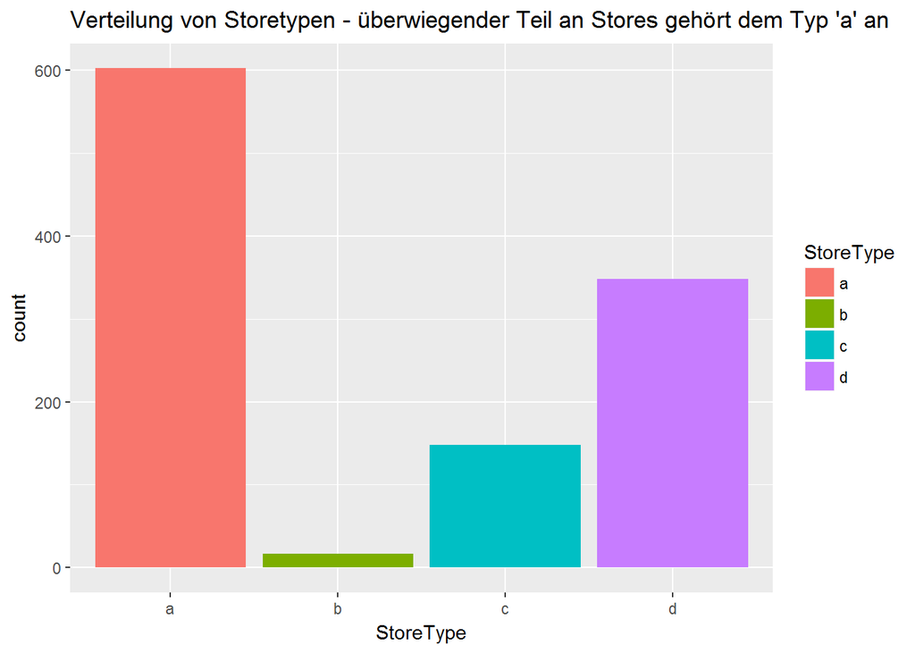

```r
#Verteilung Storetypen
ggplot(store,aes(StoreType, fill = StoreType)) + geom_bar() + ggtitle("Verteilung von Storetypen - überwiegender Teil an Stores gehört dem Typ 'a' an")
```

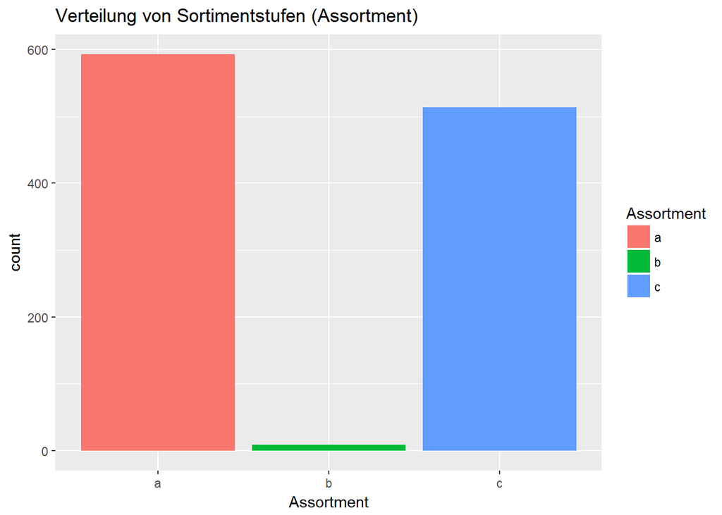

```r
#Verteilung von Sortimentstufen
ggplot(store,aes(Assortment, fill = Assortment)) + geom_bar(stat = "count") + ggtitle("Verteilung von Sortimentstufen (Assortment)")
```

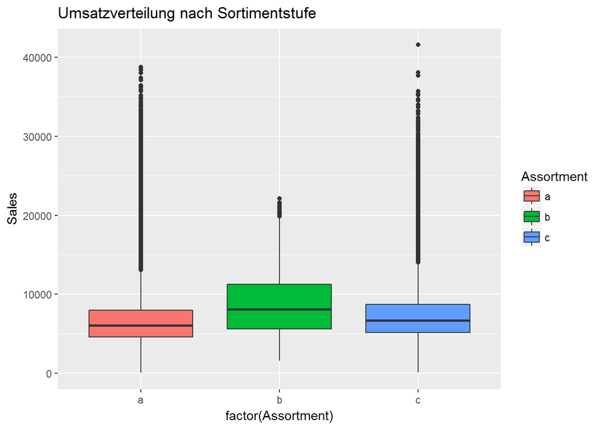

```r
#Umsatzverteilung nach Sortimentstufe
OpenUndSales <- joinedData[joinedData$Open != 0 & joinedData$Sales != 0,]
ggplot(data = OpenUndSales, aes(factor(Assortment), Sales,fill = Assortment)) + geom_boxplot() + ggtitle("Umsatzverteilung nach Sortimentstufe")
```

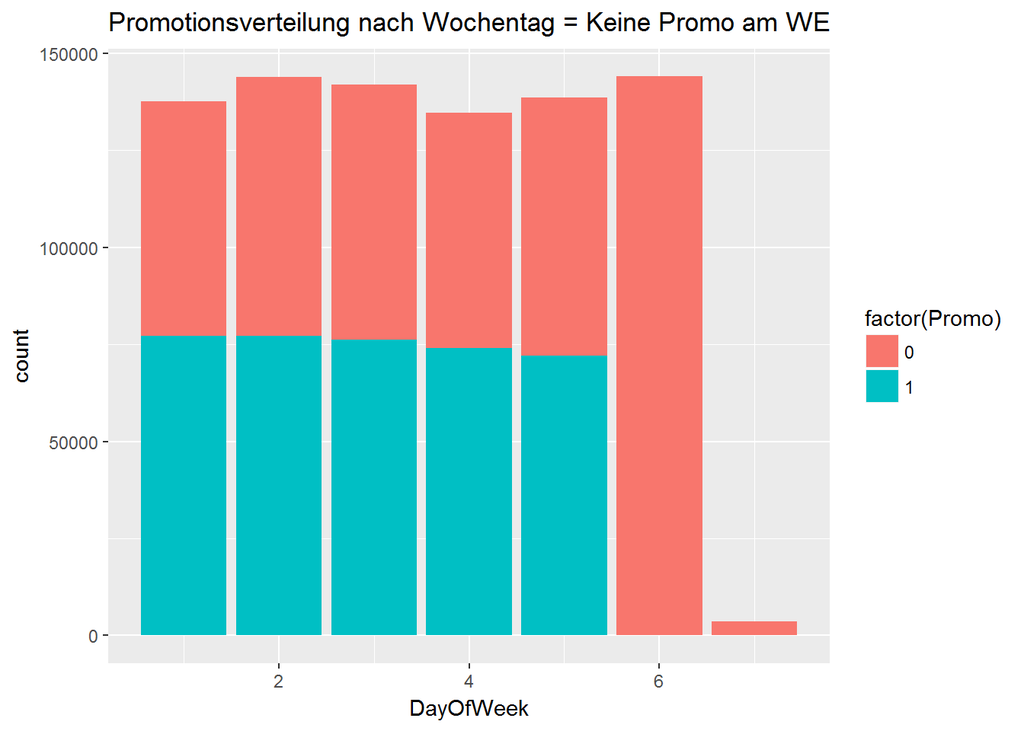

```r
#Promotionverteilung nach Wochentag
ggplot(data = OpenUndSales, aes(DayOfWeek,fill = factor(Promo))) + geom_bar() + ggtitle("Promotionsverteilung nach Wochentag = Keine Promo am WE")
```

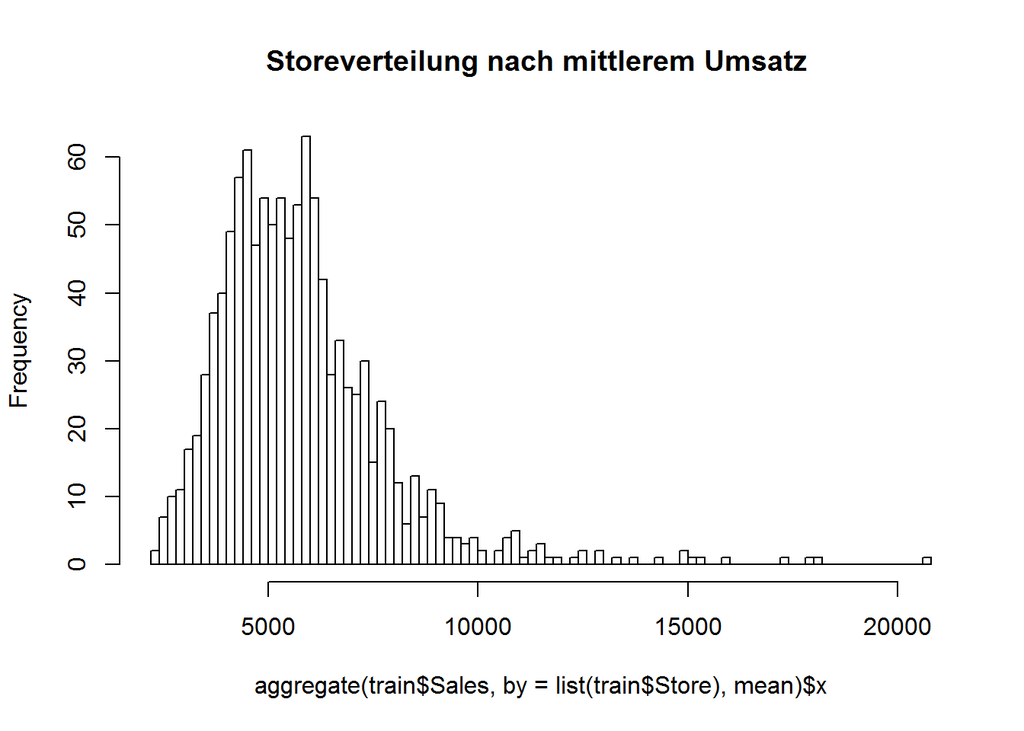

```r
#Storeverteilung nach mittlerem Umsatz
hist(aggregate(train$Sales,
               by = list(train$Store), mean)$x, 100,
     main = "Storeverteilung nach mittlerem Umsatz ")
```

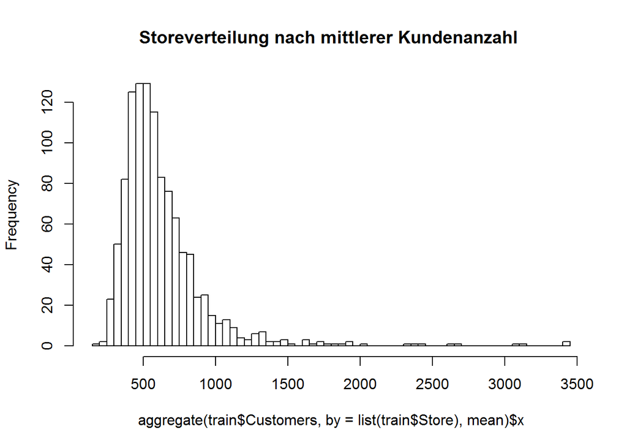

```r
#Storeverteilung nach mittlerer Kundenanzahl
hist(aggregate(train$Customers,
               by = list(train$Store), mean)$x, 100,
     main = "Storeverteilung nach mittlerer Kundenanzahl ")
```

**Ergebnis:** Auf dem ersten Blick weisen die Histographen bezogen auf Umsatz und Kundenanzahl ein ähnliches Verhalten auf. Das bedeutet, dass sie in Abhängigkeit stehen.

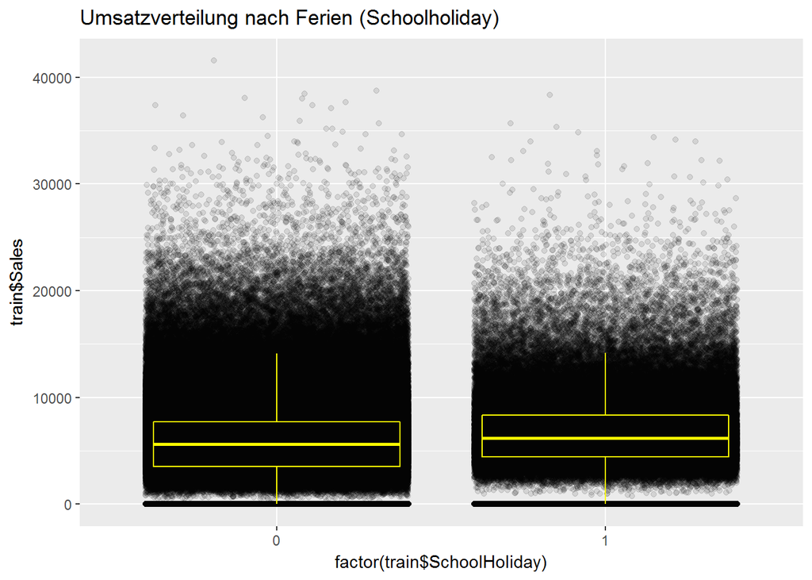

```r
#sales mit Betrachtung Schoolholiday
#install.packages("ggplot2")
library(ggplot2)
ggplot(train, aes(x = factor(train$SchoolHoliday), y = train$Sales)) +
    geom_jitter(alpha = 0.1) +
    geom_boxplot(color = "yellow", outlier.colour = NA, fill = NA) + ggtitle("Umsatzverteilung nach Ferien (Schoolholiday)")
```

**Ergebnis:** Der Graph mit der Aufteilung in Schoolholiday zeigt deutlich auf, dass der Umsatz nicht hierdurch beeinflusst wird.

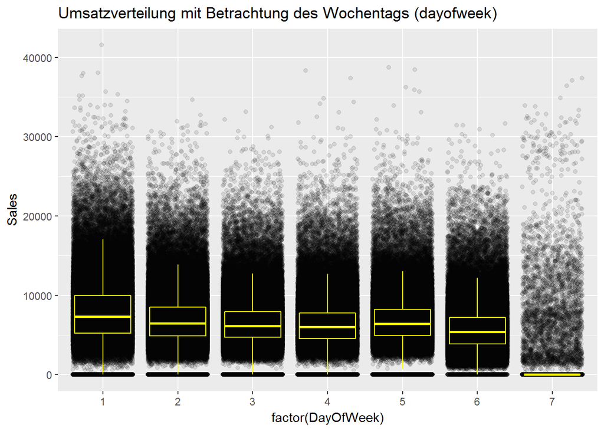

```r
#sales mit Betrachtung dayofweek (inklusive Stores mit 0 Euro Umsatz)
library("ggplot2")
ggplot(train,
       aes(x = factor(DayOfWeek), y = Sales)) +
    geom_jitter(alpha = 0.1) +
    geom_boxplot(color = "yellow", outlier.colour = NA, fill = NA)+ ggtitle("Umsatzverteilung mit Betrachtung des Wochentags (dayofweek)")
```

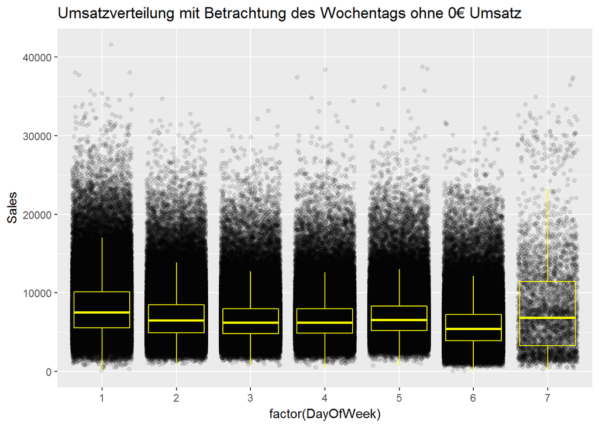

```r
#sales mit Betrachtung dayofweek (exklusive Stores mit 0 Euro Umsatz)
ggplot(train[train$Sales != "0",],
       aes(x = factor(DayOfWeek), y = Sales)) +
    geom_jitter(alpha = 0.1) +
    geom_boxplot(color = "yellow", outlier.colour = NA, fill = NA)+ ggtitle("Umsatzverteilung mit Betrachtung des Wochentags ohne 0€ Umsatz")
```

### b) Auswirkung einer Promo auf Kundenanzahl und Umsatz für kompletten Zeitraum im Trainingsdatensatz

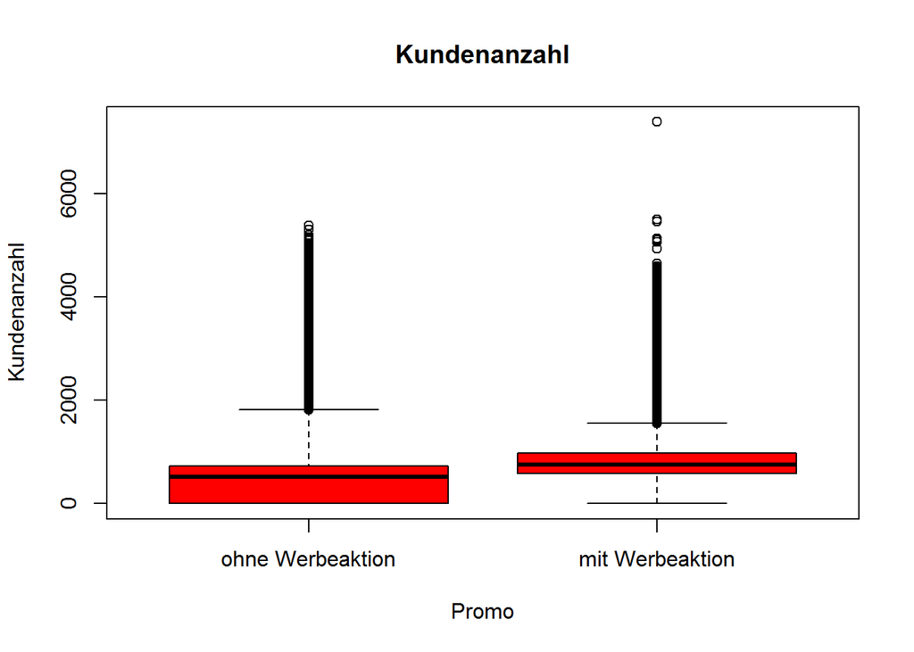

```r
# Daten  0 = keine Werbeaktion, 1 = Werbeaktion
promo_df_nein <- train[train$Promo == 0,]
promo_df_ja <- train[train$Promo == 1,]

# Boxplot customers
boxplot(promo_df_nein$Customers, promo_df_ja$Customers, names = c("ohne Werbeaktion", "mit Werbeaktion"), col = "red",main="Kundenanzahl", xlab="Promo", ylab="Kundenanzahl")
```

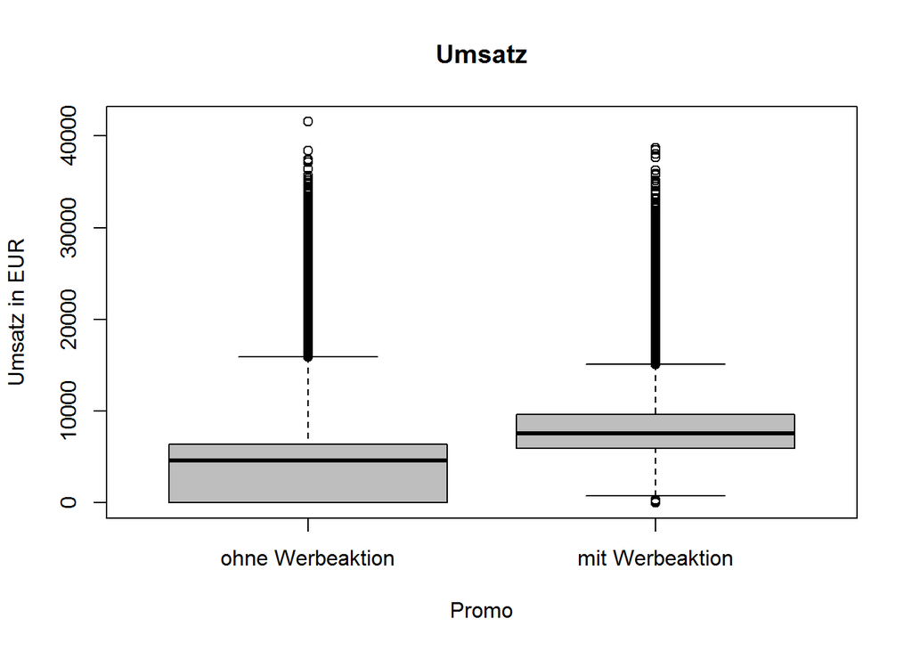

```r
# Boxplot sales
boxplot(promo_df_nein$Sales, promo_df_ja$Sales, names = c("ohne Werbeaktion", "mit Werbeaktion"), col = "grey",main="Umsatz", xlab="Promo", ylab="Umsatz in EUR")
```

**Ergebnis:** Der Umsatz ist wie erwartet stark mit der Anzahl der Kunden korreliert. Der Boxplot (Kundenanzahl) lässt sich weniger von einer Promo beeinflussen im Vergleich mit dem Boxplot (Umsatz). Dies würde bedeuten, dass die Promos nicht hauptsächlich mehr Kunden anziehen, aber lassen die Kunden mehr ausgeben.

### c) Auswirkung von dauerhaften Promoaktionen (Promo2) auf die Kundenanzahl und Umsatz für kompletten Zeitraum im Trainingsdatensatz

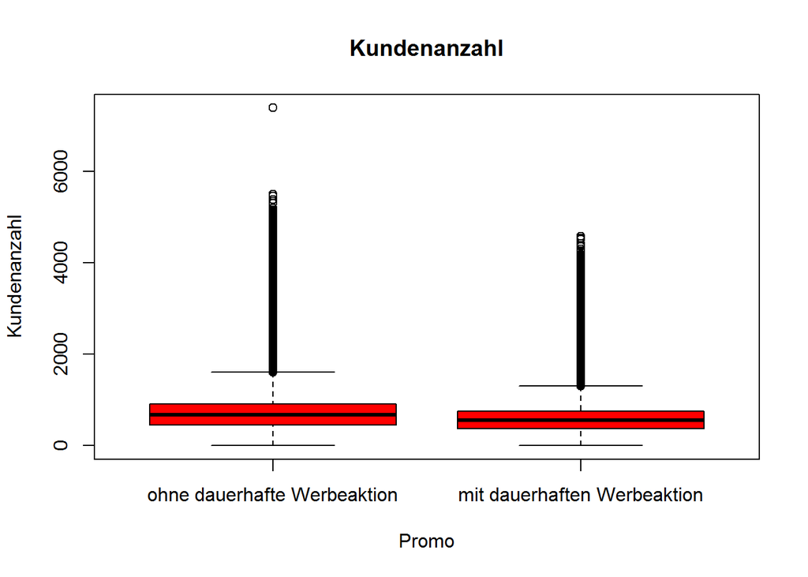

```r
# Daten  0 = keine dauerhafte Werbeaktion, 1 = dauerhafte Werbeaktion
promo2_df_nein <- joinedData[joinedData$Promo2 == 0,]
promo2_df_ja <- joinedData[joinedData$Promo2 == 1,]

# Boxplot customers
boxplot(promo2_df_nein$Customers, promo2_df_ja$Customers, names = c("ohne dauerhafte Werbeaktion", "mit dauerhaften Werbeaktion"), col = "red",main="Kundenanzahl", xlab="Promo", ylab="Kundenanzahl")
```

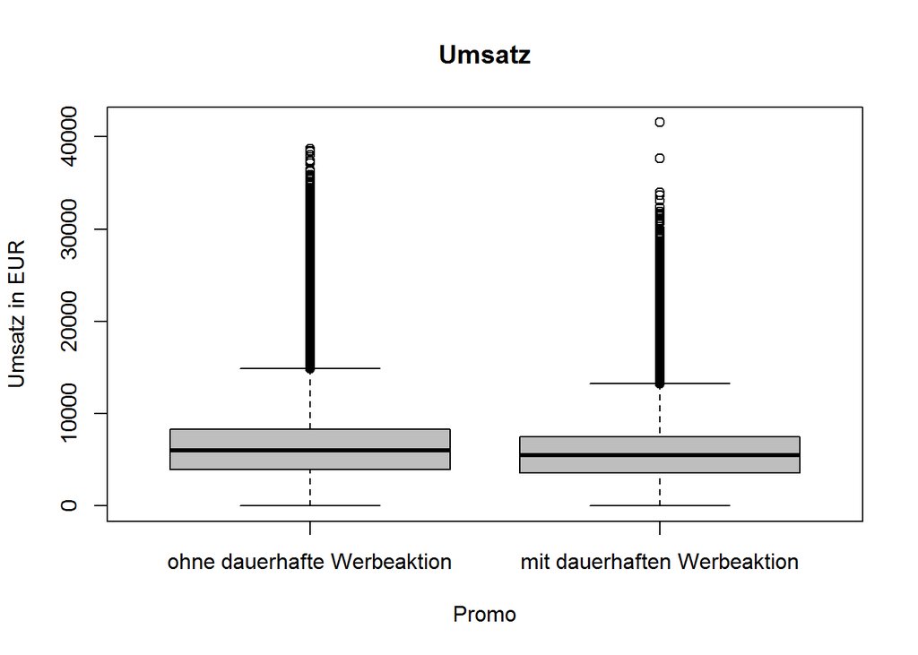

```r
# Boxplot sales
boxplot(promo2_df_nein$Sales, promo2_df_ja$Sales, names = c("ohne dauerhafte Werbeaktion", "mit dauerhaften Werbeaktion"), col = "grey",main="Umsatz", xlab="Promo", ylab="Umsatz in EUR")
```

**Bemerkung:** Die verschiedenen Promoaktionen können nicht ganzheitlich verglichen werden, da der genaue Aktionzeitraum für Promo2 nicht zur Verfügung steht. Deswegen ist ein Vergleich auf Tagesebene nicht möglich.

### d) Auswirkung einer Promo auf Kundenanzahl und Umsatz im Zeitraum des Testdatensatzes im Trainingsdatensatz 01.08 - 17.09 in den Jahren 2013 und 2014

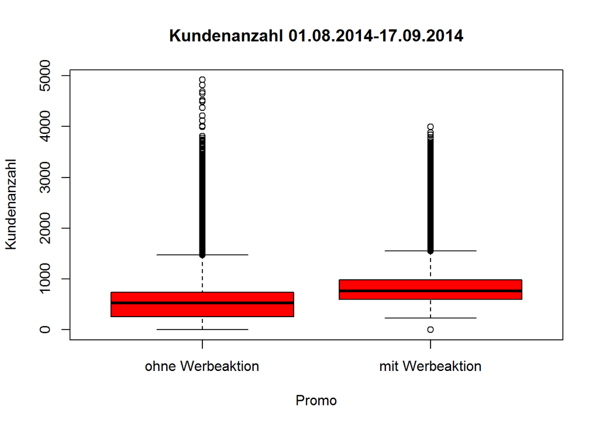

```r
#################

# Kunden- und Umsatzverhalten mit und ohne Werbeaktion im Untersuchungszeitraum für 2013 und 2014

################
train$Date <- as.character(train$Date)

zeitraum_2014 <- train[train$Date>="2014-08-01" & train$Date<="2014-09-17", ]

promo_nein_zeitraum_2014 <- zeitraum_2014[zeitraum_2014$Promo == 0,]
promo_ja_zeitraum_2014 <- zeitraum_2014[zeitraum_2014$Promo == 1,]

# Boxplot customers 2014
boxplot(promo_nein_zeitraum_2014$Customers, promo_ja_zeitraum_2014$Customers, names = c("ohne Werbeaktion", "mit Werbeaktion"), col = "red",main="Kundenanzahl 01.08.2014-17.09.2014", xlab="Promo", ylab="Kundenanzahl")
```

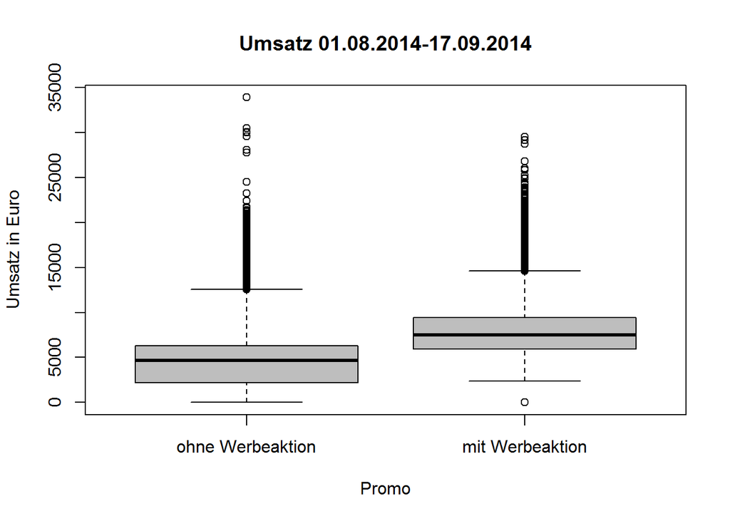

```r
# Boxplot sales 2014
boxplot(promo_nein_zeitraum_2014$Sales, promo_ja_zeitraum_2014$Sales, names = c("ohne Werbeaktion", "mit Werbeaktion"), col = "grey",main="Umsatz 01.08.2014-17.09.2014", xlab="Promo", ylab="Umsatz in Euro")
```

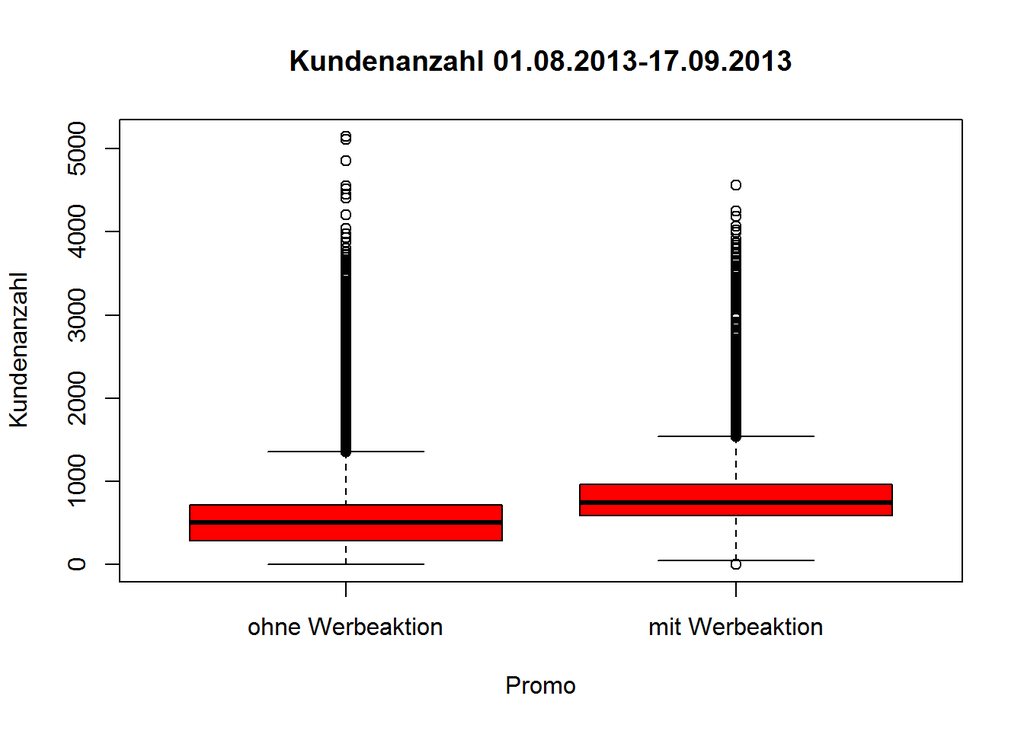

```r
zeitraum_2013 <- train[train$Date>="2013-08-01" & train$Date<="2013-09-17", ]

promo_nein_zeitraum_2013 <- zeitraum_2013[zeitraum_2013$Promo == 0,]
promo_ja_zeitraum_2013 <- zeitraum_2013[zeitraum_2013$Promo == 1,]
# Boxplot customers 2013
boxplot(promo_nein_zeitraum_2013$Customers, promo_ja_zeitraum_2013$Customers, names = c("ohne Werbeaktion", "mit Werbeaktion"), col = "red",main="Kundenanzahl 01.08.2013-17.09.2013", xlab="Promo", ylab="Kundenanzahl")
```

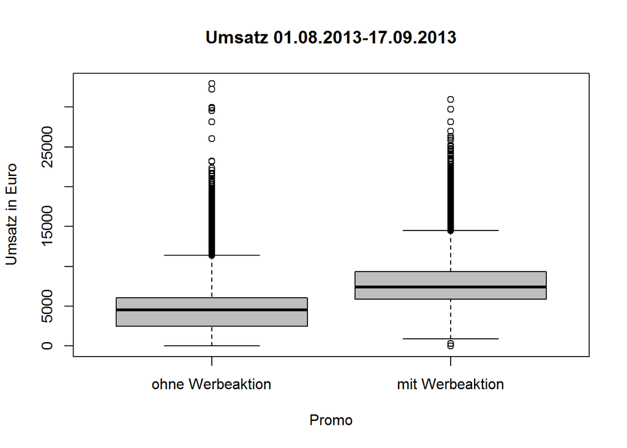

```r
# Boxplot sales 2013
boxplot(promo_nein_zeitraum_2013$Sales, promo_ja_zeitraum_2013$Sales, names = c("ohne Werbeaktion", "mit Werbeaktion"), col = "grey",main="Umsatz 01.08.2013-17.09.2013", xlab="Promo", ylab="Umsatz in Euro")
```

**Ergebnis:** Für die zu prognostizierenden Monate gab es in den vergangenen Jahren bei gleichbleibenden Aktionen keine gravierende Unterschiede, also ist mit einem ähnlichen Umsatz und Kundenverhalten zu rechnen.

### e) Visualisierung Kaufverhalten über kompletten Zeitraum im Train-Datensatz

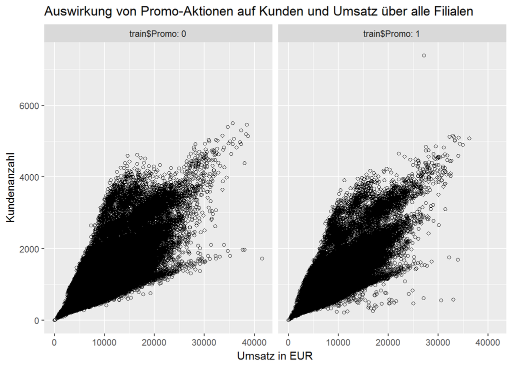

```r
# keine Promo = 0
# Promo       = 1

library(ggplot2)
sp <- ggplot(train, aes(x = train$Sales, y = train$Customers)) + geom_point(shape=1)
sp + facet_grid(. ~ train$Promo, labeller = label_both) + ggtitle("Auswirkung von Promo-Aktionen auf Kunden und Umsatz über alle Filialen") + xlab("Umsatz in EUR") + ylab("Kundenanzahl")
```

## 2.4 Gibt es Korrelationen

### a) Welche Faktoren beeinflussen sich gegenseitig

Im nächsten Schritt wird die Correlations-Matrix angewendet.

```r
# Entfernen von nicht-nummerischen unrelevanten Spalten (Date, StateHoliday, Storetype, Assortment, Promointervall...) für Correlation-Matrix
train2 <- joinedData[, -c(2,3,8,10,11,12,13,14,15,16,17,18,19)]
train_cor <- cor(train2)
train_cor[upper.tri(train_cor, diag = FALSE)] <- NA
train_cor
```

```
##                       Store      Sales  Customers      Open      Promo
## Store          1.000000e+00         NA         NA        NA         NA
## Sales          5.126226e-03 1.00000000         NA        NA         NA
## Customers      2.432487e-02 0.89471077 1.00000000        NA         NA
## Open          -4.674244e-05 0.67847235 0.61676829 1.0000000         NA
## Promo          5.786226e-05 0.45234472 0.31616948 0.2950423 1.00000000
## SchoolHoliday  6.407393e-04 0.08512404 0.07156784 0.0861706 0.06748281
##               SchoolHoliday
## Store                    NA
## Sales                    NA
## Customers                NA
## Open                     NA
## Promo                    NA
## SchoolHoliday             1
```

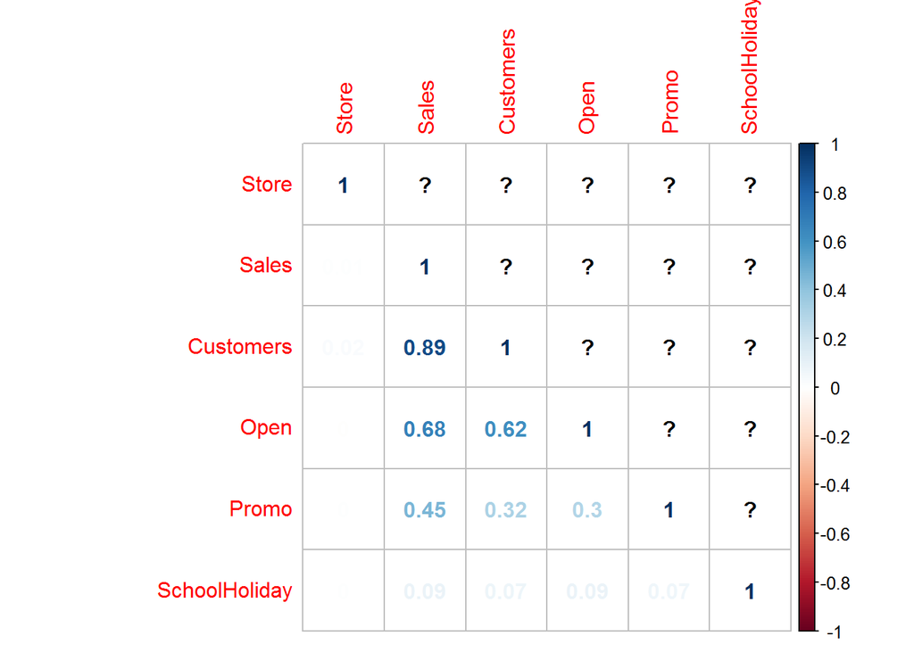

```r
library(corrplot)
corrplot(train_cor,method = "number")
```

Folgende Merkmale haben größeren Einfluss auf das Merkmal **Sales** : Customers, Open, Promo. Der Correlationskoeffizient 0.89 bei Sales-Customer bedeutet, je größer die Anzahl der Kunden, desto höher der Umsatz.

# 3. Regression

## 3.1 Definition geeigneter Merkmale und Bildung von Regressionsmodellen

Bildung eines einfachen/multiplen linearen Regressionsmodells `sales_lm` mit `sales` (*Umsatz*) als Zielvariable und weiteren Einflussmerkmalen als Input.

```r
# liniares multiples Regressionsmodell für alle Variablen --> Backward Selection
sales_lm1 <-lm(joinedData$Sales ~ . -Date , data = joinedData)
summary(sales_lm1)
```

```
##
## Call:
## lm(formula = joinedData$Sales ~ . - Date, data = joinedData)
##
## Residuals:
##     Min      1Q  Median      3Q     Max
## -9184.4  -710.0   -46.1   590.9 26265.8
##
## Coefficients: (3 not defined because of singularities)
##                                 Estimate Std. Error t value Pr(>|t|)
## (Intercept)                    4.771e+04  2.550e+03  18.712  < 2e-16 ***
## Store                         -1.079e-01  6.214e-03 -17.358  < 2e-16 ***
## DayOfWeek                     -3.486e+01  1.328e+00 -26.261  < 2e-16 ***
## Customers                      7.934e+00  8.302e-03 955.683  < 2e-16 ***
## Open                           5.785e+02  8.567e+00  67.522  < 2e-16 ***
## Promo                          1.144e+03  4.676e+00 244.577  < 2e-16 ***
## StateHoliday                          NA         NA      NA       NA
## SchoolHoliday                  4.638e+01  5.516e+00   8.409  < 2e-16 ***
## StoreTypec                    -1.857e+02  6.384e+00 -29.086  < 2e-16 ***
## StoreTyped                     9.058e+02  4.872e+00 185.932  < 2e-16 ***
## Assortmentc                    3.996e+02  4.308e+00  92.745  < 2e-16 ***
## CompetitionDistance            5.106e-02  4.018e-04 127.054  < 2e-16 ***
## CompetitionOpenSinceMonth     -1.024e+01  6.274e-01 -16.320  < 2e-16 ***
## CompetitionOpenSinceYear      -1.178e+00  2.721e-01  -4.330 1.49e-05 ***
## Promo2                                NA         NA      NA       NA
## Promo2SinceWeek                1.243e+01  1.511e-01  82.243  < 2e-16 ***
## Promo2SinceYear               -2.282e+01  1.235e+00 -18.478  < 2e-16 ***
## PromoIntervalJan,Apr,Jul,Oct   5.152e+01  5.088e+00  10.125  < 2e-16 ***
## PromoIntervalMar,Jun,Sept,Dec -4.177e+01  6.522e+00  -6.405 1.51e-10 ***
## StoreCheck                            NA         NA      NA       NA
## ---
## Signif. codes:  0 '***' 0.001 '**' 0.01 '*' 0.05 '.' 0.1 ' ' 1
##
## Residual standard error: 1119 on 313897 degrees of freedom
##   (703295 observations deleted due to missingness)
## Multiple R-squared:  0.8924, Adjusted R-squared:  0.8924
## F-statistic: 1.627e+05 on 16 and 313897 DF,  p-value: < 2.2e-16
```

```r
# perfektes Modell im Hinblick auf Komplexität sales --> Store, Customers, DayOfWeek, Open, Promo
sales_lm2 <-lm(joinedData$Sales ~ .  -Date  -StateHoliday   -SchoolHoliday  -StoreType  -Assortment -CompetitionDistance    -CompetitionOpenSinceMonth  -CompetitionOpenSinceYear   -Promo2 -Promo2SinceWeek    -Promo2SinceYear    -PromoInterval  -StoreCheck
, data = joinedData)
summary(sales_lm2)
```

```
##
## Call:
## lm(formula = joinedData$Sales ~ . - Date - StateHoliday - SchoolHoliday -
##     StoreType - Assortment - CompetitionDistance - CompetitionOpenSinceMonth -
##     CompetitionOpenSinceYear - Promo2 - Promo2SinceWeek - Promo2SinceYear -
##     PromoInterval - StoreCheck, data = joinedData)
##
## Residuals:
##     Min      1Q  Median      3Q     Max
## -8756.3  -763.6   -48.2   564.9 26450.5
##
## Coefficients:
##               Estimate Std. Error t value Pr(>|t|)
## (Intercept)  4.691e+02  1.281e+01   36.61   <2e-16 ***
## Store       -3.091e-01  7.072e-03  -43.71   <2e-16 ***
## DayOfWeek   -4.334e+01  1.522e+00  -28.48   <2e-16 ***
## Customers    7.316e+00  9.197e-03  795.50   <2e-16 ***
## Open         9.390e+02  9.789e+00   95.92   <2e-16 ***
## Promo        1.225e+03  5.400e+00  226.91   <2e-16 ***
## ---
## Signif. codes:  0 '***' 0.001 '**' 0.01 '*' 0.05 '.' 0.1 ' ' 1
##
## Residual standard error: 1296 on 313908 degrees of freedom
##   (703295 observations deleted due to missingness)
## Multiple R-squared:  0.8557, Adjusted R-squared:  0.8557
## F-statistic: 3.723e+05 on 5 and 313908 DF,  p-value: < 2.2e-16
```

```r
# einfaches lineares Modell sales --> customer
sales_lm3 <-lm(joinedData$Sales ~ .  -Date -Store -DayOfWeek -Promo -Open -StateHoliday -SchoolHoliday  -StoreType  -Assortment -CompetitionDistance    -CompetitionOpenSinceMonth  -CompetitionOpenSinceYear   -Promo2 -Promo2SinceWeek    -Promo2SinceYear    -PromoInterval  -StoreCheck
, data = joinedData)
summary(sales_lm3)
```

```
##
## Call:
## lm(formula = joinedData$Sales ~ . - Date - Store - DayOfWeek -
##     Promo - Open - StateHoliday - SchoolHoliday - StoreType -
##     Assortment - CompetitionDistance - CompetitionOpenSinceMonth -
##     CompetitionOpenSinceYear - Promo2 - Promo2SinceWeek - Promo2SinceYear -
##     PromoInterval - StoreCheck, data = joinedData)
##
## Residuals:
##      Min       1Q   Median       3Q      Max
## -12442.6   -685.4   -269.9    776.4  27478.4
##
## Coefficients:
##              Estimate Std. Error t value Pr(>|t|)
## (Intercept) 5.778e+02  4.943e+00   116.9   <2e-16 ***
## Customers   8.737e+00  7.351e-03  1188.4   <2e-16 ***
## ---
## Signif. codes:  0 '***' 0.001 '**' 0.01 '*' 0.05 '.' 0.1 ' ' 1
##
## Residual standard error: 1455 on 313912 degrees of freedom
##   (703295 observations deleted due to missingness)
## Multiple R-squared:  0.8182, Adjusted R-squared:  0.8182
## F-statistic: 1.412e+06 on 1 and 313912 DF,  p-value: < 2.2e-16
```

```r
# lineares Modell auf Basis vom Entscheidungsbaum und Regressionsbaum (siehe Punkt 9) Sales --> Customers, Promo, StoreType
# Entscheidungsbaum, Regressionsbaum folgt weiter unten
sales_lm4 <-lm(joinedData$Sales ~ .  -Date -Store -DayOfWeek -Open  -StateHoliday   -SchoolHoliday  -Assortment -CompetitionDistance    -CompetitionOpenSinceMonth  -CompetitionOpenSinceYear   -Promo2 -Promo2SinceWeek    -Promo2SinceYear    -PromoInterval  -StoreCheck
, data = joinedData)
summary(sales_lm4)
```

```
##
## Call:
## lm(formula = joinedData$Sales ~ . - Date - Store - DayOfWeek -
##     Open - StateHoliday - SchoolHoliday - Assortment - CompetitionDistance -
##     CompetitionOpenSinceMonth - CompetitionOpenSinceYear - Promo2 -
##     Promo2SinceWeek - Promo2SinceYear - PromoInterval - StoreCheck,
##     data = joinedData)
##
## Residuals:
##      Min       1Q   Median       3Q      Max
## -10559.2   -750.9     26.2    601.8  25878.9
##
## Coefficients:
##               Estimate Std. Error  t value Pr(>|t|)
## (Intercept) -2.618e+01  4.775e+00   -5.483 4.18e-08 ***
## Customers    8.362e+00  6.743e-03 1240.088  < 2e-16 ***
## Promo        1.218e+03  4.825e+00  252.436  < 2e-16 ***
## StoreTypec  -2.336e+02  6.581e+00  -35.499  < 2e-16 ***
## StoreTyped   1.200e+03  4.854e+00  247.278  < 2e-16 ***
## ---
## Signif. codes:  0 '***' 0.001 '**' 0.01 '*' 0.05 '.' 0.1 ' ' 1
##
## Residual standard error: 1201 on 313909 degrees of freedom
##   (703295 observations deleted due to missingness)
## Multiple R-squared:  0.8762, Adjusted R-squared:  0.8762
## F-statistic: 5.552e+05 on 4 and 313909 DF,  p-value: < 2.2e-16
```

```r
# Vergleich der Modelle
anova(sales_lm1, sales_lm2,sales_lm3,sales_lm4)
```

```
## Analysis of Variance Table
##
## Model 1: joinedData$Sales ~ (Store + DayOfWeek + Date + Customers + Open +
##     Promo + StateHoliday + SchoolHoliday + StoreType + Assortment +
##     CompetitionDistance + CompetitionOpenSinceMonth + CompetitionOpenSinceYear +
##     Promo2 + Promo2SinceWeek + Promo2SinceYear + PromoInterval +
##     StoreCheck) - Date
## Model 2: joinedData$Sales ~ (Store + DayOfWeek + Date + Customers + Open +
##     Promo + StateHoliday + SchoolHoliday + StoreType + Assortment +
##     CompetitionDistance + CompetitionOpenSinceMonth + CompetitionOpenSinceYear +
##     Promo2 + Promo2SinceWeek + Promo2SinceYear + PromoInterval +
##     StoreCheck) - Date - StateHoliday - SchoolHoliday - StoreType -
##     Assortment - CompetitionDistance - CompetitionOpenSinceMonth -
##     CompetitionOpenSinceYear - Promo2 - Promo2SinceWeek - Promo2SinceYear -
##     PromoInterval - StoreCheck
## Model 3: joinedData$Sales ~ (Store + DayOfWeek + Date + Customers + Open +
##     Promo + StateHoliday + SchoolHoliday + StoreType + Assortment +
##     CompetitionDistance + CompetitionOpenSinceMonth + CompetitionOpenSinceYear +
##     Promo2 + Promo2SinceWeek + Promo2SinceYear + PromoInterval +
##     StoreCheck) - Date - Store - DayOfWeek - Promo - Open - StateHoliday -
##     SchoolHoliday - StoreType - Assortment - CompetitionDistance -
##     CompetitionOpenSinceMonth - CompetitionOpenSinceYear - Promo2 -
##     Promo2SinceWeek - Promo2SinceYear - PromoInterval - StoreCheck
## Model 4: joinedData$Sales ~ (Store + DayOfWeek + Date + Customers + Open +
##     Promo + StateHoliday + SchoolHoliday + StoreType + Assortment +
##     CompetitionDistance + CompetitionOpenSinceMonth + CompetitionOpenSinceYear +
##     Promo2 + Promo2SinceWeek + Promo2SinceYear + PromoInterval +
##     StoreCheck) - Date - Store - DayOfWeek - Open - StateHoliday -
##     SchoolHoliday - Assortment - CompetitionDistance - CompetitionOpenSinceMonth -
##     CompetitionOpenSinceYear - Promo2 - Promo2SinceWeek - Promo2SinceYear -
##     PromoInterval - StoreCheck
##   Res.Df        RSS  Df   Sum of Sq       F    Pr(>F)
## 1 313897 3.9333e+11
## 2 313908 5.2741e+11 -11 -1.3408e+11  9727.9 < 2.2e-16 ***
## 3 313912 6.6457e+11  -4 -1.3716e+11 27365.7 < 2.2e-16 ***
## 4 313909 4.5257e+11   3  2.1200e+11 56395.3 < 2.2e-16 ***
## ---
## Signif. codes:  0 '***' 0.001 '**' 0.01 '*' 0.05 '.' 0.1 ' ' 1
```

## 3.2 Visualisierung von verschiedenen Regressionsmodellen auf allen Stores und weitere deskriptive Analyse

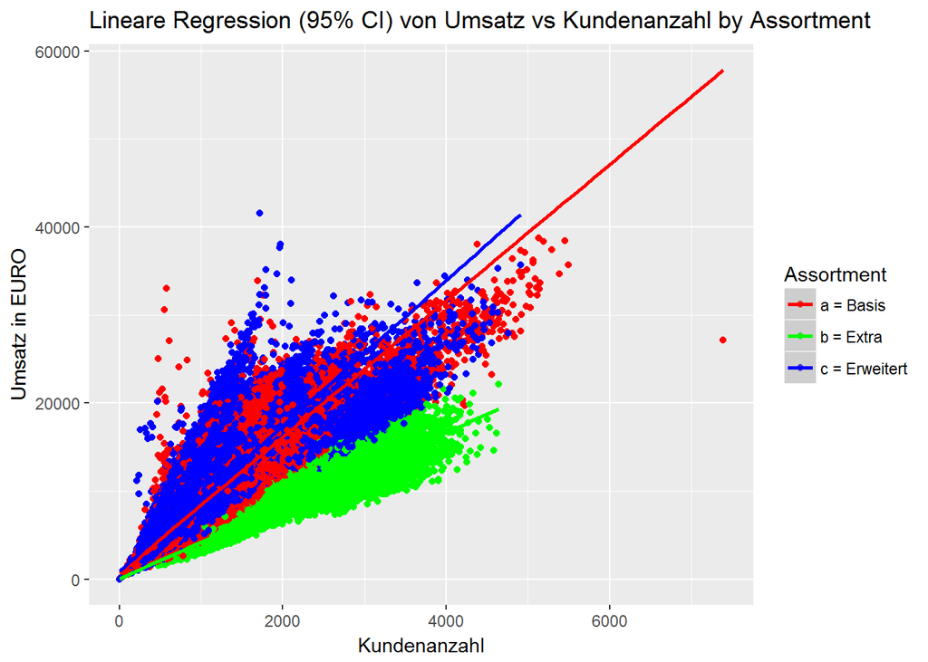

```r
#Basis Plot Kunden --> Umsatz farbig unterschieden nach Assortment
p1 <- ggplot(joinedData, aes(x = Customers, y = Sales))
p4 <- p1 + geom_point(aes(color=factor(joinedData$Assortment))) +
  geom_smooth(aes(color=factor(joinedData$Assortment)),method = "lm", se = TRUE) +
  scale_color_manual(name ="Assortment",
                     labels=c("a = Basis","b = Extra", "c = Erweitert"),
                     values=c("red","green", "blue")) +
  scale_shape_manual(name ="Assortment",
                     labels=c("a = Basis","b = Extra", "c = Erweitert"),
                     values=c(0,0,2)) +

  labs(x="Kundenanzahl",
       y = "Umsatz in EURO",
       title= "Lineare Regression (95% CI) von Umsatz vs Kundenanzahl by Assortment")
p4
```

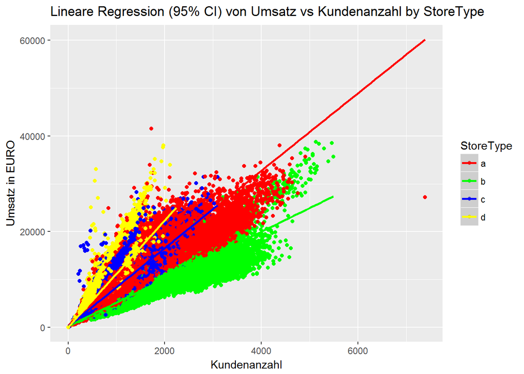

```r
#Basis Plot Kunden --> Umsatz farbig unterschieden nach Storetype
p2 <- ggplot(joinedData, aes(x = Customers, y = Sales))
p5 <- p2 + geom_point(aes(color=factor(joinedData$StoreType))) +
  geom_smooth(aes(color=factor(joinedData$StoreType)),method = "lm", se = TRUE) +
  scale_color_manual(name ="StoreType",
                     labels=c("a","b", "c","d"),
                     values=c("red","green", "blue", "yellow")) +
  scale_shape_manual(name ="StoreType",
                     labels=c("a","b", "c", "d"),
                     values=c(0,0,0,2)) +

  labs(x="Kundenanzahl",
       y = "Umsatz in EURO",
       title= "Lineare Regression (95% CI) von Umsatz vs Kundenanzahl by StoreType")
p5
```

```r
#Übersicht Anzahl verschiedener Assortment
data.frame(table(store$Assortment))
```

```
##   Var1 Freq
## 1    a  593
## 2    b    9
## 3    c  513
```

```r
#Übersicht Anzahl verschiedener Storetypen
data.frame(table(store$StoreType))
```

```
##   Var1 Freq
## 1    a  602
## 2    b   17
## 3    c  148
## 4    d  348
```

```r
#Übersicht Storetype/Assortment Kombination
table(data.frame(Assortment = store$Assortment, StoreType = store$StoreType))
```

```
##           StoreType
## Assortment   a   b   c   d
##          a 381   7  77 128
##          b   0   9   0   0
##          c 221   1  71 220
```

```r
store_df_a <- joinedData[joinedData$StoreType == "a",]
store_df_a_mean <- mean(store_df_a$Sales)

store_df_b <- joinedData[joinedData$StoreType == "b",]
store_df_b_mean <- mean(store_df_b$Sales)

store_df_c <- joinedData[joinedData$StoreType == "c",]
store_df_c_mean <- mean(store_df_c$Sales)

store_df_d <- joinedData[joinedData$StoreType == "d",]
store_df_d_mean <- mean(store_df_d$Sales)

#gemittelte Umsätze nach Storetypen mit graphischer Visualisierung
umsatz_mean_storetypes <- c(store_df_a_mean,store_df_b_mean,store_df_c_mean, store_df_d_mean)
umsatz_mean_storetypes
```

```
## [1]  5738.180 10058.837  5723.629  5641.819
```

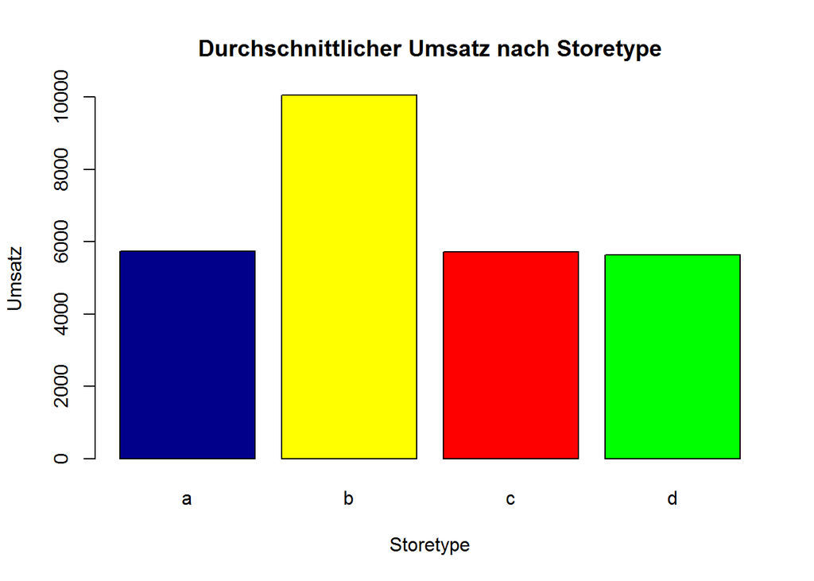

```r
#Durchschnittlicher Umsatz nach Storetype
barplot(umsatz_mean_storetypes, main="Durchschnittlicher Umsatz nach Storetype", xlab = "Storetype", ylab = "Umsatz", col = c("darkblue", "yellow", "red", "green"), names.arg = c("a","b","c","d"))
```

**Ergebnis:** Auf Grundlage von Storetype und Assortment wurden verschiedene Regressionsmodelle in den Plot “Lineare Regression (95% CI) von Umsatz vs Kundenanzahl by Assortment/StoreType” ergänzt. Anhand der Verteilung der verschiedenen Datenpunkte (Stores) ist ersichtlich, dass unterschiedliche lineare Modelle bezogen auf Storetype und Assortment sinnvoll sind. Storetype d hat die wenigsten Kunden, diese generieren aber am meisten Umsatz im Verhältnis. Storetype d bietet nur Sortiementstufen (a,c) Basis und Erweitert an. Auffällig ist, dass es im Verhältnis sehr wenige Assortment b und Storetyps b gibt. Mutmaßlich würde man davon ausgehen von Storetype b auf d zu wechseln, um mehr Umsatz zu generieren. Aber guckt man sich die Umsätze gruppiert nach Storetypen an (letzter Plot), macht b am meisten Umsatz.

## 3.3 Visualisierung von verschiedenen Regressionsmodellen auf spezifischen Store

```r
#Eigenschaften Store 1000: Storetyp = a, Assortment = c
#subset für store 1000 für kompletten Zeitraum
store_df_1000 <- joinedData[joinedData$Store == "1000",]
#Spalten Sales, Customer auswählen
store_df_1000 <- store_df_1000[4:5]
summary(store_df_1000)
```

```
##      Sales         Customers
##  Min.   :    0   Min.   :  0.0
##  1st Qu.: 5535   1st Qu.:555.2
##  Median : 6853   Median :643.5
##  Mean   : 6115   Mean   :558.9
##  3rd Qu.: 8105   3rd Qu.:726.8
##  Max.   :12459   Max.   :979.0
```

```r
#View(store_df_1000)

#linerares Modell für Sales --> Customer auf Basis des oben entwickelten Modells 'sales_lm3'
lm_sales_store1000 <-lm(Sales ~ Customers, data = store_df_1000)

#Vorhersage für Kundenanzahl von 300 - 800
predict(lm_sales_store1000, newdata = data.frame(Customers = c(300,500,800)))
```

```
##        1        2        3
## 3191.616 5449.958 8837.470
```

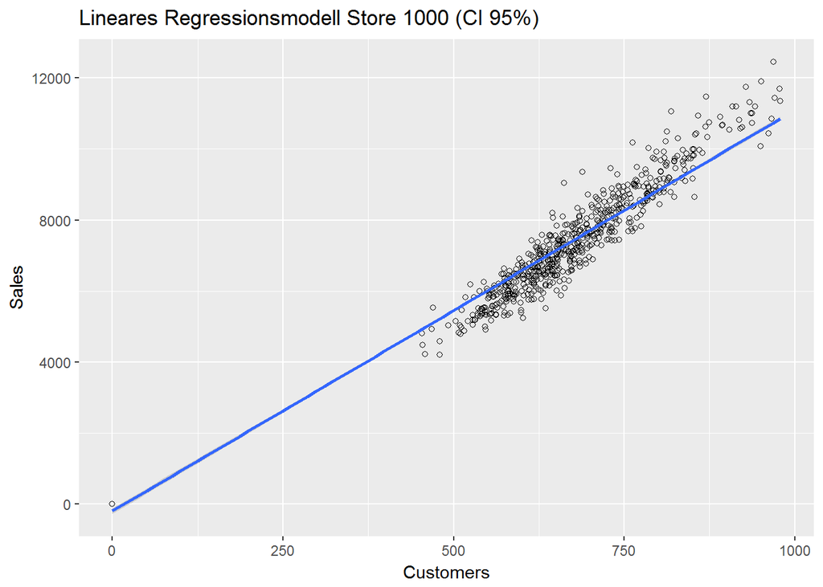

```r
library(ggplot2)
ggplot(lm_sales_store1000, aes(x=Customers, y=Sales)) + geom_point(shape=1) +
    geom_smooth(method=lm,   # Regressionslinie hinzufügen
                level = 0.95,    # Konfidenzintervall hinzufügen
                fullrange=TRUE)+ ggtitle("Lineares Regressionsmodell Store 1000 (CI 95%)")
```

```r
#Perfektes Modell --> Spalten Sales, Customer, Open, Promo auswählen (Bais: Modell 'sales_lm2')
store_df_1000 <- joinedData[joinedData$Store == "1000",]
store_df_1000_erweitert<- store_df_1000[4:7]
#summary(store_df_1000_erweitert)
#View(store_df_1000_erweitert)
#linerares Modell für Store 1000 für Customer, Promo --> Sales
lm_sales_store1000_erweitert <-lm(Sales ~ Customers + Promo, data = store_df_1000_erweitert)
summary(lm_sales_store1000_erweitert)
```

```
##
## Call:
## lm(formula = Sales ~ Customers + Promo, data = store_df_1000_erweitert)
##
## Residuals:
##      Min       1Q   Median       3Q      Max
## -1222.57  -327.01    35.88   173.45  1763.50
##
## Coefficients:
##               Estimate Std. Error t value Pr(>|t|)
## (Intercept) -173.45409   36.27012  -4.782 2.08e-06 ***
## Customers     10.87877    0.06425 169.311  < 2e-16 ***
## Promo        552.23522   36.66058  15.063  < 2e-16 ***
## ---
## Signif. codes:  0 '***' 0.001 '**' 0.01 '*' 0.05 '.' 0.1 ' ' 1
##
## Residual standard error: 442.5 on 755 degrees of freedom
## Multiple R-squared:  0.9805, Adjusted R-squared:  0.9805
## F-statistic: 1.899e+04 on 2 and 755 DF,  p-value: < 2.2e-16
```

```r
#Vorhersage des Umsatzes für Kundenanzahl von 300 - 800 ohne Promo
predict(lm_sales_store1000_erweitert, newdata = data.frame(Customers = c(300,500,800),Promo = c(0,0,0)))
```

```
##        1        2        3
## 3090.178 5265.932 8529.564
```

```r
#Vorhersage des Umsatzes für Kundenanzahl von 300 - 800 mit Promo
predict(lm_sales_store1000_erweitert, newdata = data.frame(Customers = c(300,500,800),Promo = c(1,1,1)))
```

```
##        1        2        3
## 3642.413 5818.167 9081.799
```

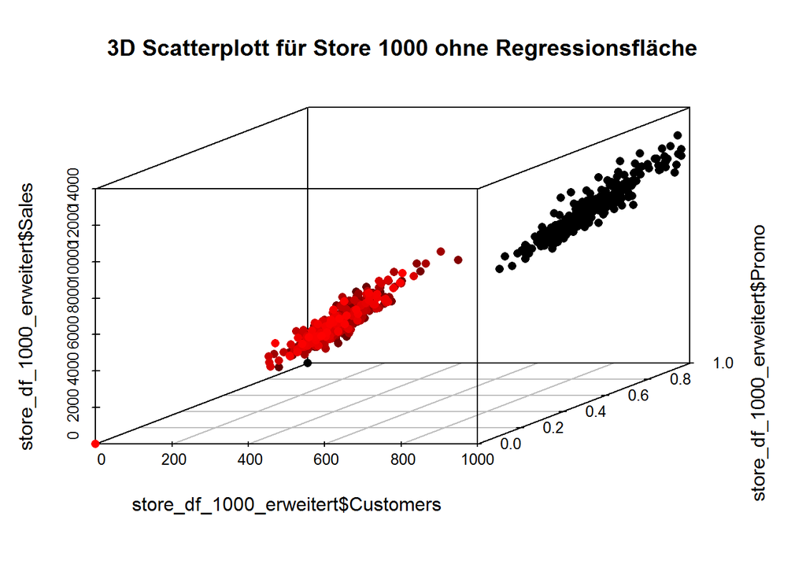

```r
# 3D scatterplot der Daten von Store 1000
library(scatterplot3d)
scatterplot3d(x=store_df_1000_erweitert$Customers, y=store_df_1000_erweitert$Promo, z=store_df_1000_erweitert$Sales, highlight.3d=TRUE, pch=16, main = "3D Scatterplott für Store 1000 ohne Regressionsfläche")
```

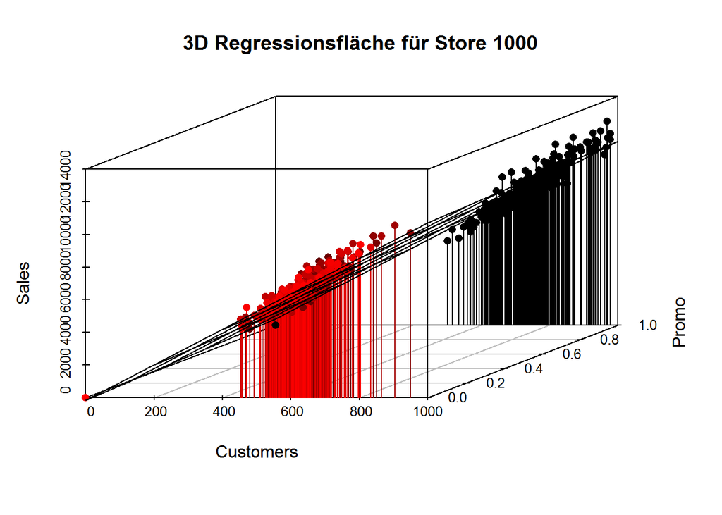

```r
# hinzufügen einer regressionsfläche
s3d <- scatterplot3d(x=store_df_1000_erweitert$Customers, y=store_df_1000_erweitert$Promo, z=store_df_1000_erweitert$Sales, highlight.3d=TRUE, pch=16, type = "h", main = "3D Regressionsfläche für Store 1000", xlab = "Customers", ylab =" Promo", zlab = "Sales" )
s3d$plane3d(lm_sales_store1000_erweitert, lty="solid")  # Regressionsfläche vom linearen Model "lm_sales_store1000_erweitert""
```

```r
observed.3d <- s3d$xyz.convert(store_df_1000_erweitert$Customers, store_df_1000_erweitert$Promo, store_df_1000_erweitert$Sales)  # Datenpunkte
predicted.3d <- s3d$xyz.convert(store_df_1000_erweitert$Customers, store_df_1000_erweitert$Sales, fitted(lm_sales_store1000_erweitert)) # Treffer der Regressionsfläche anzeigen
```

**Ergebnis:** Der erste Plot visualisiert das einfache Model mit Customer als Eingangsvariable und Sales als Zielvariable für Store 1000. Der zweite Plot stellt die Datenpunkte in einer Ebene dar, inklusive farblicher Aufteilung bezogen auf Promo. Der dritte Plot stellt die drei Variablen Sales, Customer und Promo im Verhältnis zur Regressionsfläche dar. Schaut man sich die predicted values an, so wird bei ‘lm_sales_store1000_erweitert’ deutlich, dass bei durchgeführten Promos mehr Umsatz generiert werden kann.

## 3.4 Kreuzvalidierung für lineares Regressionsmodell

```
## Analysis of Variance Table
##
## Response: Sales
##            Df   Sum Sq  Mean Sq F value Pr(>F)
## Customers   1 7.39e+09 7.39e+09   37756 <2e-16 ***
## Promo       1 4.44e+07 4.44e+07     227 <2e-16 ***
## Residuals 755 1.48e+08 1.96e+05
## ---
## Signif. codes:  0 '***' 0.001 '**' 0.01 '*' 0.05 '.' 0.1 ' ' 1
```

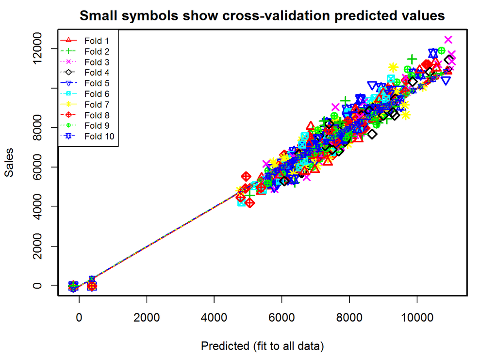

[output not shown]

[output cut: 449 more lines]

[output not shown]

```r
# 10-fache Kreuzvalidierung auf subset für store 1000 für kompletten Zeitraum (Spalten Sales, Customer, Open, Promo)
cv_lm <- cv.lm(store_df_1000_erweitert, form.lm = lm_sales_store1000_erweitert, m=10, dots =
      FALSE, seed=29, plotit=TRUE, printit=TRUE)
```

```r
attr(cv_lm, 'ms')
```

```
## [1] 196583
```

**Ergebnis:** Um zu testen, ob das erzeugte Modell die ganze Zeit über gut funktioniert, wurde die Kreuzvalidierung angewendet. Durch die Kreuzvalidierung wird die Modellqualität überprüft. Aus den Berechnungen der mittleren quadratischen Fehler der Vorhersagen wird der Durchschnitt dieser quadratischen mittleren Fehler (k-Abschnitte) berechnet -> hier ist es ms 196583. Sinngemäß sollte dieses Vorgehen für alle weiteren Modelle angewendet werden, um einen Modellvergleich durchzuführen. Aufgrund des erhöhten Outputs wurde dies nicht gemacht.

# 4. Benchmarking - Mittelwert für Store ‘1000’ im Testzeitraum vs lineares Modell

```r
# Dataframe für Store 1000 erstellen
store_df_1000 <- train[train$Store == "1000",]
# View(store_df_1000)
store_df_1000$Date <- as.character(store_df_1000$Date)

# Datensatz filtern auf den Zeitraum 6 Wochen zurück und Wochentag 'Freitag'
zeitraum_6WochenZurueck <- store_df_1000[store_df_1000$Date>="2015-06-26" & store_df_1000$Date<="2015-07-31" & store_df_1000$DayOfWeek == "5",]
# View(zeitraum_6WochenZurueck)
mittelwertZeitraum_6WochenZurueck <- mean(zeitraum_6WochenZurueck$Sales)
mittelwertZeitraum_6WochenZurueck
```

```
## [1] 6947
```

```r
#### Benchmarkvergleich mit erarbeitetem Regressionsmodell

lm_sales_store1000_erweitert2 <-lm(Sales ~ Customers + DayOfWeek , data = store_df_1000)
# Mittelwertbestimmung Kunden
mittelwertKundenanzahl6Wochenzurueck <- mean(zeitraum_6WochenZurueck$Customers)
# mittelwertKundenanzahl6Wochenzurueck

# Mittelwertbestimmung für das predicted modell
mean(predict(lm_sales_store1000_erweitert2, newdata = data.frame(Customers = mittelwertKundenanzahl6Wochenzurueck, DayOfWeek = 5, Promo = 1, Promo = 0)))
```

```
## [1] 6886
```

**Ergebnis:** In der Analyse wurden die Verkaufszahlen der Filiale 1000 als Mittelwert der letzten 6 Wochen für den selben Wochentag (hier: Freitag) ermittelt. Der durchschnittliche Umsatz der letzten Wochen wird verglichen mit unseren bisherigen Modellen. Es ist ersichtlich, dass es keine gravierenden Unterschiede gibt, folglich ist die Modellerstellung für präzise Resultate lohnenswert.

# 5. Klassifikation

## 5.1 Bildung eines logistischen Regressionsmodells auf sample Datensatz

```r
#logistisches Modell --> Promo

set.seed(1)
train_sample_1000 <- joinedData[sample(1:dim(joinedData)[1],1000),]

#train_sample <- createDataPartition(train_sample_1000$Promo, p =0.5, list = FALSE)    # stratified sample ergänzen
#train_sample

fit <- glm(Promo ~ Sales, data = train_sample_1000, family = binomial)
#plot(fit)

# Klassen-Wahrscheinlichkeiten
props <- predict(fit, type="response")

# Klassifizieren mittels Schwellenwert
classify <- function(x, threshold) {
  ifelse(x > threshold, 1, 0)
}
actuals <- ifelse(train_sample_1000$Promo == 1, 1, 0)

threshold_05 <- 0.5
predicted <- classify(props,threshold_05)
# Definition von Promo = "1"als positive Klasse als Kennzahl
library(caret)
confusionMatrix(predicted, actuals, positive = "1")
```

```
## Confusion Matrix and Statistics
##
##           Reference
## Prediction   0   1
##          0 577 186
##          1  70 167
##
##                Accuracy : 0.744
##                  95% CI : (0.716, 0.771)
##     No Information Rate : 0.647
##     P-Value [Acc > NIR] : 2.95e-11
##
##                   Kappa : 0.394
##  Mcnemar's Test P-Value : 6.60e-13
##
##             Sensitivity : 0.473
##             Specificity : 0.892
##          Pos Pred Value : 0.705
##          Neg Pred Value : 0.756
##              Prevalence : 0.353
##          Detection Rate : 0.167
##    Detection Prevalence : 0.237
##       Balanced Accuracy : 0.682
##
##        'Positive' Class : 1
##
```

### a) Festlegen und Änderung des Schwellenwertes für Konfusionsmatrix

```r
threshold_03 <- 0.3
predicted <- classify(props,threshold_03)
confusionMatrix(predicted, actuals, positive = "1")
```

```
## Confusion Matrix and Statistics
##
##           Reference
## Prediction   0   1
##          0 411  58
##          1 236 295
##
##                Accuracy : 0.706
##                  95% CI : (0.677, 0.734)
##     No Information Rate : 0.647
##     P-Value [Acc > NIR] : 4.38e-05
##
##                   Kappa : 0.423
##  Mcnemar's Test P-Value : < 2e-16
##
##             Sensitivity : 0.836
##             Specificity : 0.635
##          Pos Pred Value : 0.556
##          Neg Pred Value : 0.876
##              Prevalence : 0.353
##          Detection Rate : 0.295
##    Detection Prevalence : 0.531
##       Balanced Accuracy : 0.735
##
##        'Positive' Class : 1
##
```

```r
threshold_08 <- 0.8
predicted <- classify(props,threshold_08)
confusionMatrix(predicted, actuals, positive = "1")
```

```
## Confusion Matrix and Statistics
##
##           Reference
## Prediction   0   1
##          0 632 316
##          1  15  37
##
##                Accuracy : 0.669
##                  95% CI : (0.639, 0.698)
##     No Information Rate : 0.647
##     P-Value [Acc > NIR] : 0.0769
##
##                   Kappa : 0.101
##  Mcnemar's Test P-Value : <2e-16
##
##             Sensitivity : 0.105
##             Specificity : 0.977
##          Pos Pred Value : 0.712
##          Neg Pred Value : 0.667
##              Prevalence : 0.353
##          Detection Rate : 0.037
##    Detection Prevalence : 0.052
##       Balanced Accuracy : 0.541
##
##        'Positive' Class : 1
##
```

### b) Bilden einer ROC-Kurve

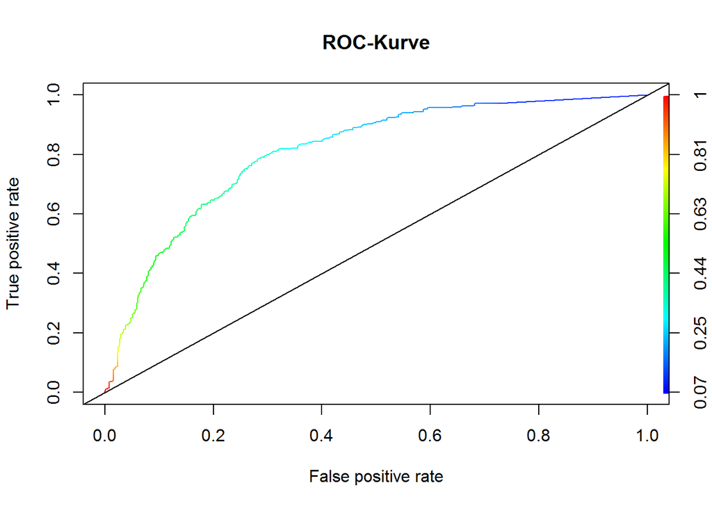

```r
#ziel --> um AUC zu berechnen, bestes Modell und bester Schwellenwert
library(ROCR)
ROCRpred <- prediction(props, actuals)

ROCRperf <- performance(ROCRpred, 'tpr','fpr')
plot(ROCRperf, colorize = TRUE, text.adj = c(-0.2,1.7), main = "ROC-Kurve")
abline(0,1)
```

```r
?plot
```

```
## starting httpd help server ...
```

```
##  done
```

```r
# Ermittlung des AUC-Wertes für Modellqualität
performance(ROCRpred, "auc")@y.values
```

```
## [[1]]
## [1] 0.81
```

### c) Schwellenwertbestimmung und Kostenanalyse

```r
# Zuweisen von Kosten für kostenbewusste Entscheidungen
model_cost <- function(cost_matrix, confusion_matrix) {
  sum(cost_matrix * confusion_matrix)}
threshold_vektor <- seq(0.1, 0.9, 0.1)

# Kosten definieren:
# False Positives: Keine Promo stattgefunden, aber Promo vorhergesagt -> Kosten von 300 -> Umsatzverlust
# False Negatives: Promo stattgefunden, jedoch nicht vorhergesagt -> Kosten von 200 -> Kosten für Promo
costs <- matrix(c(0, 200, 300, 0), nrow = 2)

# Gegenüberstellung Schwellenwert und Kosten
cost_by_threshold <- data.frame(threshold=threshold_vektor,
                                costs=vector(length = length(threshold_vektor)))
for (i in (1:length(threshold_vektor))) {
  predicted <- classify(props,threshold_vektor[i])
  conf_matrix <- confusionMatrix(predicted, actuals, positive = "1")
  cost_by_threshold$costs[i] <- model_cost(costs, conf_matrix$table)}

cost_by_threshold
```

```
##   threshold  costs
## 1       0.1  96800
## 2       0.2  82900
## 3       0.3  64600
## 4       0.4  63700
## 5       0.5  69800
## 6       0.6  79800
## 7       0.7  88800
## 8       0.8  97800
## 9       0.9 103100
```

```r
# Ermittlung bester Schwellenwert/ geringste Kosten
best_index <- which.min(cost_by_threshold$costs)
best_index
```

```
## [1] 4
```

```r
best_threshold <- cost_by_threshold$threshold[best_index]
best_threshold
```

```
## [1] 0.4
```

```r
best_costs <- cost_by_threshold$costs[best_index]
best_costs
```

```
## [1] 63700
```

**Ergebnis:** In diesem Abschnitt wird untersucht mit welcher Wahrscheinlichkeit das Eintreten von Promo von Sales abhängt. Ausgangspunkt ist ein sample von 1000 Datensätzen aus joinedData. Aus diesem wird das logistische Regressionsmodell erstellt. Verschiedene Schwellenwerte werden für die Erstellung der Konfusionmatix betrachtet. Aus der ROC-Kurve ist ersichtlich, das der Schwellenwert zwischen 0.3 und 0.4 am geeignetesten ist. Zudem können wir aus der Konfusionsmatrix erkennen, dass die Verteilung von TPR und FNR in diesem Bereich am besten ist. Des weiteren wurde eine Kostenfunktion erstellt mit fiktiven Kosten und den Schwellenwerten gegenübergestellt. Die Güte des logistischen Modells beträgt nach Berechnung ca 81 %.

## 5.2 Bildung eines logistischen Regressionsmodells auf stratifizierten Datensatz

```r
# Bildung von stratifizierten Datensatz mit p = 0.001 -> gleiche Verteiltung bezüglich Promo
strat_trainedData_1018 <- joinedData[createDataPartition(joinedData$Promo , p = 0.001, list = FALSE),]
strat_trainedData_1000 <- strat_trainedData_1018[sample(1:dim(strat_trainedData_1018)[1],1000),]

n2 <- nrow(strat_trainedData_1000)
n2
```

```
## [1] 1000
```

```r
actuals2 <- ifelse(strat_trainedData_1000$Promo == 1, 1, 0)

# stratifiziertes sampling
stratified_sample <- sample(1:n2, n2 * 0.8, replace = FALSE)
#nrow(stratified_sample)
train_indices<- createDataPartition(joinedData$Promo, p = 0.001, list = FALSE)

# Modell erstellen mit Trainingsdaten
fit2 <- glm(Promo ~ Sales, data = strat_trainedData_1000, family = binomial, subset = stratified_sample)

props <- predict(fit2, newdata = strat_trainedData_1000[-train_indices,], type="response")

threshold <- 0.3 # Schwellenwert von oben

# klassifizieren nach Schwellenwert
predicted <- classify(props,threshold)

# die Klasse "1" spezifizieren als positive Klasse für performance Kennzahlen
confusionMatrix(predicted, actuals2[-train_indices], positive = "1")
```

```
## Confusion Matrix and Statistics
##
##           Reference
## Prediction   0   1
##          0 339  43
##          1 277 341
##
##                Accuracy : 0.68
##                  95% CI : (0.65, 0.709)
##     No Information Rate : 0.616
##     P-Value [Acc > NIR] : 1.48e-05
##
##                   Kappa : 0.393
##  Mcnemar's Test P-Value : < 2e-16
##
##             Sensitivity : 0.888
##             Specificity : 0.550
##          Pos Pred Value : 0.552
##          Neg Pred Value : 0.887
##              Prevalence : 0.384
##          Detection Rate : 0.341
##    Detection Prevalence : 0.618
##       Balanced Accuracy : 0.719
##
##        'Positive' Class : 1
##
```

**Ergebnis:** An dieser Stelle ziehen wir 0.001 Prozent stratifizierte Datensätze, die das Verhältis im Bezug zum kompletten Datensatz widerspiegeln. Dieses Modell sollte bessere Werte liefern als das sample-Modell, wird jedoch nur durch den Sensitivity-Wert ersichtlich.

## 5.3 Kreuzvalidierung für erzeugte logistische Regressionsmodelle (sample/stratifiziert)

```r
# 10-fache Kreuzvalidierung auf sample
cv_glm <- cv.glm(train_sample_1000, fit, K=10)
# gemittelte Missklassifikationsrate
cv_glm$delta
```

```
## [1] 0.173 0.173
```

```r
# 10-fache Kreuzvalidierung auf stratifizierten Datensatz
strat_trainedData_1000_ohne_NA <- na.omit(strat_trainedData_1000)# NA entfernen
#nrow(strat_trainedData_1000_ohne_NA)
cv_gl <- cv.glm(strat_trainedData_1000_ohne_NA, fit2, K=10)
# gemittelte Missklassifikationsrate
cv_gl$delta
```

```
## [1] 0.310 0.192
```

**Ergebnis:** Durch die Anwendung einer Kreuzvalidierung wird die Modellqualität überprüft. Wie bereits oben ersichtlich ist das stratifizierte Modell ungenauer. Dieses wird auch durch den ersten Wert(roher Durchschnitt der Fehlklassifizierungsrate) deutlich. Erwartungsmäß sollte durch den Einsatz eines statifizierten Modells eine bessere Modellgüte erzielt werden.

# 6. K-nearest neighbour für Klassenzuordnung

## 6.1 K-nearest neighbour - (Predictors: Sales, Customer) –> (Class: Assortment)

```r
#k-nearest neighbour mit Eingangsparametern Sales und Customer und Ausgangsparameter Assortment
zeitraum_2014_1_tag <- joinedData[joinedData$Date=="01.08.2014" , ]
stratified_join<- zeitraum_2014_1_tag[createDataPartition(zeitraum_2014_1_tag$Assortment, p = 0.1, list = FALSE),]

n <- nrow(stratified_join) #Anzahl Datensätze
#View(train_sample_1000)

#Aufteilung in Trainings- und Testdatensatz
train_indices <- sample(1:n, round(2/3 * n))
train_sample_1000_train <- stratified_join[train_indices,]
train_sample_1000_test <- stratified_join[-train_indices,]

# auf zwei Eingabe-Features trainieren
# zwei features ausgewählt, sodass lineare Trennung gut funktioniert
features <- c("Sales", "Customers")
cols <- c(features, "Assortment")

# 10 fache Kreuzvalidierung
ctrl <- trainControl(method="cv", number = 5)

# hier werden verschiedene K-Werte ausprobiert
knnfit <- train(Assortment ~ ., data = stratified_join[, cols], method = "knn", trControl = ctrl,
                preProcess = c("center","scale"),
                tuneGrid = expand.grid(k=3:20)) # try k=3,4, ... 20
#Ergebnis von kNN fit
knnfit
```

```
## k-Nearest Neighbors
##
## 94 samples
##  2 predictor
##  3 classes: 'a', 'b', 'c'
##
## Pre-processing: centered (2), scaled (2)
## Resampling: Cross-Validated (5 fold)
## Summary of sample sizes: 74, 76, 75, 76, 75
## Resampling results across tuning parameters:
##
##   k   Accuracy  Kappa
##    3  0.459     -0.07231
##    4  0.499     -0.00285
##    5  0.497     -0.01373
##    6  0.471     -0.06985
##    7  0.523      0.03782
##    8  0.552      0.09525
##    9  0.524      0.03970
##   10  0.537      0.06624
##   11  0.550      0.09277
##   12  0.564      0.11773
##   13  0.591      0.17670
##   14  0.578      0.15076
##   15  0.591      0.17758
##   16  0.659      0.31848
##   17  0.618      0.23314
##   18  0.632      0.26241
##   19  0.632      0.26026
##   20  0.659      0.31582
##
## Accuracy was used to select the optimal model using the largest value.
## The final value used for the model was k = 20.
```

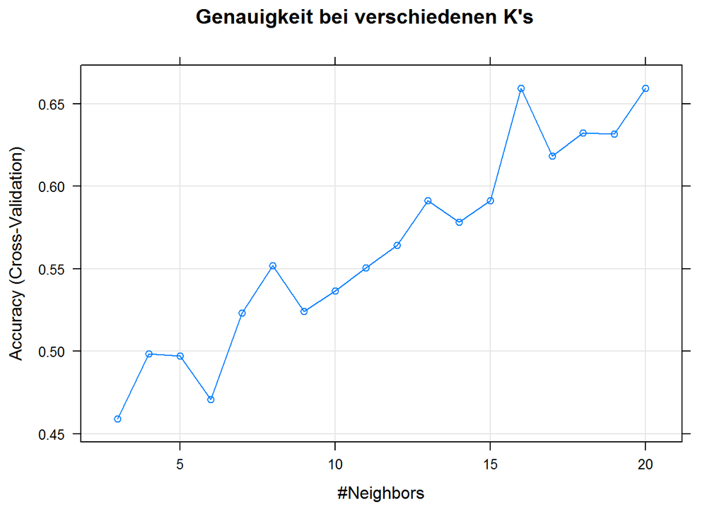

```r
plot(knnfit, main=" Genauigkeit bei verschiedenen K's")
```

```r
# Klassenvorhersage
knnPredict <- predict(knnfit, newdata = stratified_join[, cols] )

# Konfusionsmatrix und Genauigkeit
confusionMatrix(knnPredict, stratified_join$Assortment)
```

```
## Confusion Matrix and Statistics
##
##           Reference
## Prediction  a  b  c
##          a 33  1 12
##          b  0  0  0
##          c 15  0 33
##
## Overall Statistics
##
##                Accuracy : 0.702
##                  95% CI : (0.599, 0.792)
##     No Information Rate : 0.511
##     P-Value [Acc > NIR] : 0.000126
##
##                   Kappa : 0.411
##  Mcnemar's Test P-Value : NA
##
## Statistics by Class:
##
##                      Class: a Class: b Class: c
## Sensitivity             0.688   0.0000    0.733
## Specificity             0.717   1.0000    0.694
## Pos Pred Value          0.717      NaN    0.688
## Neg Pred Value          0.688   0.9894    0.739
## Prevalence              0.511   0.0106    0.479
## Detection Rate          0.351   0.0000    0.351
## Detection Prevalence    0.489   0.0000    0.511
## Balanced Accuracy       0.702   0.5000    0.714
```

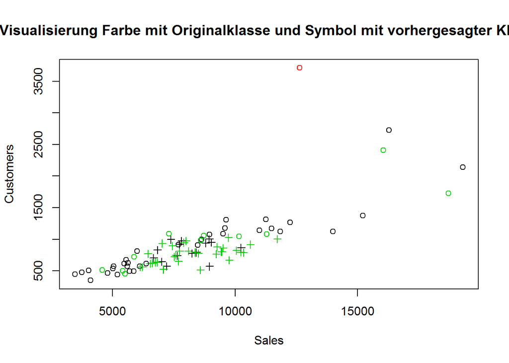

```r
# Visualisierung Farbe mit Originalklasse und Symbol mit vorhergesagter Klasse
plot(stratified_join[,features], col=stratified_join$Assortment, pch=as.numeric(unclass(knnPredict)), main=" Visualisierung Farbe mit Originalklasse und Symbol mit vorhergesagter Klasse")
```

**Ergebnis:** Mittels des k-Nearest-Neighbour classifiers wurde versucht das beste k für die höchste Genauigkeit (Vorhersage) von Assortment mit den Eingangparametern Sales und Customers zu bestimmen. Der finale k-Wert für das eingesetzte Modell ist der Konsolenausgabe zu entnehmen, da es sich jeweils um eine andere stratifizierte Datenbasis handelt.

```r
# auf zwei Eingabe-Features trainieren
# zwei features ausgewählt, sodass lineare Trennung gut funktioniert
features2 <- c("Sales", "CompetitionDistance")
cols2 <- c(features, "StoreType")

ctrl <- trainControl(method="cv", number = 5) # 5-fold cross validation

# hier werden verschiedene K-Werte ausprobiert
knnfit <- train(StoreType ~ ., data = stratified_join[, cols2], method = "knn", trControl = ctrl,
                preProcess = c("center","scale"),
                tuneGrid = expand.grid(k=3:20)) # try k=3,4, ... 20

#Ergebnis von kNN fit
knnfit
```

```
## k-Nearest Neighbors
##
## 94 samples
##  2 predictor
##  4 classes: 'a', 'b', 'c', 'd'
##
## Pre-processing: centered (2), scaled (2)
## Resampling: Cross-Validated (5 fold)
## Summary of sample sizes: 75, 76, 74, 75, 76
## Resampling results across tuning parameters:
##
##   k   Accuracy  Kappa
##    3  0.469     0.0802
##    4  0.499     0.1077
##    5  0.563     0.2034
##    6  0.575     0.2296
##    7  0.596     0.2439
##    8  0.585     0.2429
##    9  0.619     0.2975
##   10  0.533     0.1469
##   11  0.566     0.2060
##   12  0.607     0.2450
##   13  0.618     0.2753
##   14  0.585     0.1975
##   15  0.628     0.2798
##   16  0.627     0.2681
##   17  0.639     0.2936
##   18  0.629     0.2694
##   19  0.607     0.2135
##   20  0.617     0.2414
##
## Accuracy was used to select the optimal model using the largest value.
## The final value used for the model was k = 17.
```

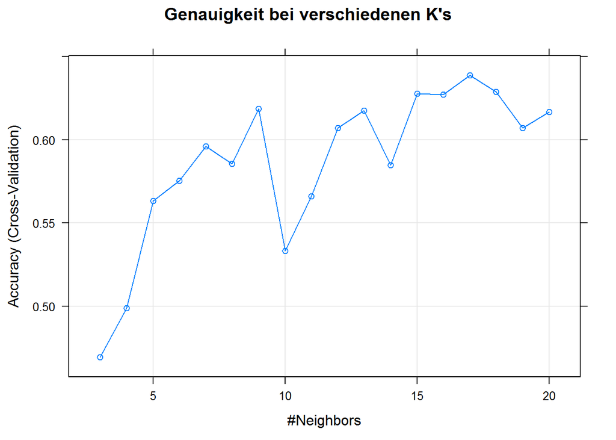

```r
plot(knnfit, main= "Genauigkeit bei verschiedenen K's")
```

```r
# predict the classes in the entire data set using the best model
knnPredict <- predict(knnfit, newdata = stratified_join[, cols2] )

# Konfusionsmatrix und Genauigkeit
confusionMatrix(knnPredict, stratified_join$StoreType)
```

```
## Confusion Matrix and Statistics
##
##           Reference
## Prediction  a  b  c  d
##          a 45  2 13 10
##          b  0  0  0  0
##          c  0  0  0  0
##          d  6  0  2 16
##
## Overall Statistics
##
##                Accuracy : 0.649
##                  95% CI : (0.544, 0.745)
##     No Information Rate : 0.543
##     P-Value [Acc > NIR] : 0.0238
##
##                   Kappa : 0.332
##  Mcnemar's Test P-Value : NA
##
## Statistics by Class:
##
##                      Class: a Class: b Class: c Class: d
## Sensitivity             0.882   0.0000     0.00    0.615
## Specificity             0.419   1.0000     1.00    0.882
## Pos Pred Value          0.643      NaN      NaN    0.667
## Neg Pred Value          0.750   0.9787     0.84    0.857
## Prevalence              0.543   0.0213     0.16    0.277
## Detection Rate          0.479   0.0000     0.00    0.170
## Detection Prevalence    0.745   0.0000     0.00    0.255
## Balanced Accuracy       0.650   0.5000     0.50    0.749
```

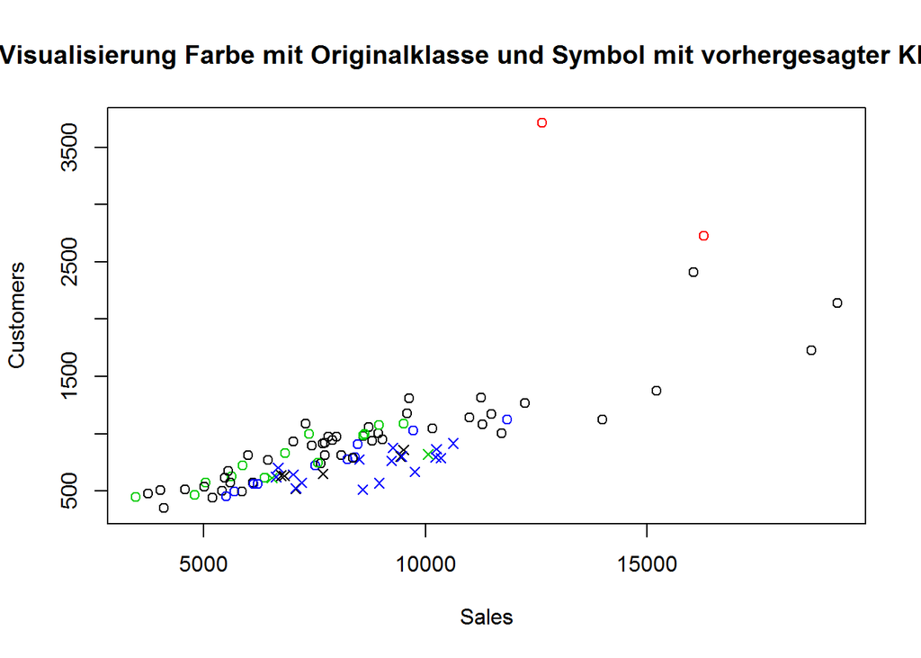

```r
# Visualisierung Farbe mit Originalklasse und Symbol mit vorhergesagter Klasse
plot(stratified_join[,features], col=stratified_join$StoreType, pch=as.numeric(unclass(knnPredict)), main=" Visualisierung Farbe mit Originalklasse und Symbol mit vorhergesagter Klasse")
```

**Bemerkung:** Als Vergleich zum oberen Beispiel wurden hier andere Predictors und Klassen gewählt.

# 7. Support vector machine

```r
# svm trainieren
library(e1071)
svmfit <- svm(Assortment ~ ., data = train_sample_1000_train[,cols], kernel = "linear",
              cost = 1, scale = TRUE)

# Ergebnis
print(svmfit)
```

```
##
## Call:
## svm(formula = Assortment ~ ., data = train_sample_1000_train[,
##     cols], kernel = "linear", cost = 1, scale = TRUE)
##
##
## Parameters:
##    SVM-Type:  C-classification
##  SVM-Kernel:  linear
##        cost:  1
##       gamma:  0.5
##
## Number of Support Vectors:  54
```

```r
#zusätzliche Infomationen
summary(svmfit)
```

```
##
## Call:
## svm(formula = Assortment ~ ., data = train_sample_1000_train[,
##     cols], kernel = "linear", cost = 1, scale = TRUE)
##
##
## Parameters:
##    SVM-Type:  C-classification
##  SVM-Kernel:  linear
##        cost:  1
##       gamma:  0.5
##
## Number of Support Vectors:  54
##
##  ( 26 27 1 )
##
##
## Number of Classes:  3
##
## Levels:
##  a b c
```

```r
# indices des support vectors
svmfit$index
```

```
##  [1]  1  2  3  4  6  8  9 10 17 18 20 24 25 29 30 31 32 38 43 44 46 47 49
## [24] 52 56 57  5  7 12 13 14 15 16 21 22 23 27 28 33 35 37 42 48 50 51 53
## [47] 54 55 58 59 60 62 63 39
```

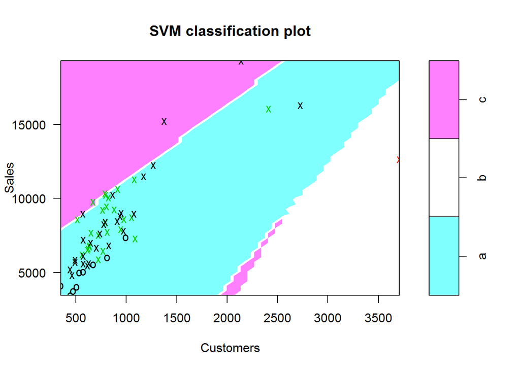

```r
# plot mit support vektoren (hyperplanes)
plot(svmfit, train_sample_1000_train[,cols])
```

```r
# Vorhersage auf dem Testdatensatz
prediction <- predict(svmfit, train_sample_1000_test, type = "class", na.action = na.pass)

# Confusionsmatrix
confusionMatrix(prediction, train_sample_1000_test[,"Assortment"])
```

```
## Confusion Matrix and Statistics
##
##           Reference
## Prediction  a  b  c
##          a 10  0 17
##          b  0  0  0
##          c  2  0  2
##
## Overall Statistics
##
##                Accuracy : 0.387
##                  95% CI : (0.218, 0.578)
##     No Information Rate : 0.613
##     P-Value [Acc > NIR] : 0.997
##
##                   Kappa : -0.05
##  Mcnemar's Test P-Value : NA
##
## Statistics by Class:
##
##                      Class: a Class: b Class: c
## Sensitivity             0.833       NA   0.1053
## Specificity             0.105        1   0.8333
## Pos Pred Value          0.370       NA   0.5000
## Neg Pred Value          0.500       NA   0.3704
## Prevalence              0.387        0   0.6129
## Detection Rate          0.323        0   0.0645
## Detection Prevalence    0.871        0   0.1290
## Balanced Accuracy       0.469       NA   0.4693
```

**Ergebnis:** Über die Anwendung des SVM-Verfahrens haben wir versucht eine lineare Trennung bzgl. der Klassen (hier “Assortment”) vorzunehmen. Wie ersichtlich, bietet das SVM-Verfahren keine hohe Genauigkeit. Folglich wird im weiteren Verlauf nicht näher darauf eingegangen